# Ensemble Techniques Project - Harshavardhana Shridhar Bhat

## PART A

#### DOMAIN:

Telecom

#### CONTEXT:

A telecom company wants to use their historical customer data to predict behaviour to retain customers. You can analyse all relevant customer data and develop focused customer retention programs.

#### DATA DESCRIPTION:

Each row represents a customer, each column contains customer’s attributes described on the column Metadata. The data set includes information about: • Customers who left within the last month – the column is called Churn • Services that each customer has signed up for – phone, multiple lines, internet, online security, online backup, device protection, tech support, and streaming TV and movies • Customer account information – how long they’ve been a customer, contract, payment method, paperless billing, monthly charges, and total charges • Demographic info about customers – gender, age range, and if they have partners and dependents

#### PROJECT OBJECTIVE:

To Build a model that will help to identify the potential customers who have a higher probability to churn. This helps the company to understand the pinpoints and patterns of customer churn and will increase the focus on strategizing customer retention.

```python
#Importing required packages
import numpy             as np
import pandas            as pd
import matplotlib.pyplot as plt
import seaborn as sns
from sklearn.model_selection import train_test_split
from sklearn.preprocessing import MinMaxScaler
from sklearn.metrics import classification_report
from sklearn.model_selection import GridSearchCV
from sklearn.tree import DecisionTreeClassifier
from sklearn.ensemble import RandomForestClassifier
from sklearn.ensemble import AdaBoostClassifier
from sklearn.ensemble import GradientBoostingClassifier
from sklearn.tree import export_graphviz
from IPython.display import Image
from sklearn.tree import plot_tree
from sklearn import metrics
from sklearn.metrics import confusion_matrix
from sklearn.metrics import make_scorer

%matplotlib inline
```

### STEPS AND TASK [30 Marks]:

#### 1. Data Understanding & Exploration: [5 Marks]

#### A. Read ‘TelcomCustomer-Churn_1.csv’ as a DataFrame and assign it to a variable. [1 Mark]

```python
df_churn1 = pd.read_csv('TelcomCustomer-Churn_1.csv')
```

```python
df_churn1.head()
```

|  | customerID | gender | SeniorCitizen | Partner | Dependents | tenure | PhoneService | MultipleLines | InternetService | OnlineSecurity |
| --- | --- | --- | --- | --- | --- | --- | --- | --- | --- | --- |
| 0 | 7590-VHVEG | Female | 0 | Yes | No | 1 | No | No phone service | DSL | No |
| 1 | 5575-GNVDE | Male | 0 | No | No | 34 | Yes | No | DSL | Yes |
| 2 | 3668-QPYBK | Male | 0 | No | No | 2 | Yes | No | DSL | Yes |
| 3 | 7795-CFOCW | Male | 0 | No | No | 45 | No | No phone service | DSL | Yes |
| 4 | 9237-HQITU | Female | 0 | No | No | 2 | Yes | No | Fiber optic | No |

```python
df_churn1.info()
```

```
<class 'pandas.core.frame.DataFrame'>
RangeIndex: 7043 entries, 0 to 7042
Data columns (total 10 columns):
 #   Column           Non-Null Count  Dtype
---  ------           --------------  -----
 0   customerID       7043 non-null   object
 1   gender           7043 non-null   object
 2   SeniorCitizen    7043 non-null   int64
 3   Partner          7043 non-null   object
 4   Dependents       7043 non-null   object
 5   tenure           7043 non-null   int64
 6   PhoneService     7043 non-null   object
 7   MultipleLines    7043 non-null   object
 8   InternetService  7043 non-null   object
 9   OnlineSecurity   7043 non-null   object
dtypes: int64(2), object(8)
memory usage: 550.4+ KB
```

#### B. Read ‘TelcomCustomer-Churn_2.csv’ as a DataFrame and assign it to a variable. [1 Mark]

```python
df_churn2 = pd.read_csv('TelcomCustomer-Churn_2.csv')
```

```python
df_churn2.head()
```

|  | customerID | OnlineBackup | DeviceProtection | TechSupport | StreamingTV | StreamingMovies | Contract | PaperlessBilling | PaymentMethod | MonthlyCharges | TotalCharges | Churn |
| --- | --- | --- | --- | --- | --- | --- | --- | --- | --- | --- | --- | --- |
| 0 | 7590-VHVEG | Yes | No | No | No | No | Month-to-month | Yes | Electronic check | 29.85 | 29.85 | No |
| 1 | 5575-GNVDE | No | Yes | No | No | No | One year | No | Mailed check | 56.95 | 1889.5 | No |
| 2 | 3668-QPYBK | Yes | No | No | No | No | Month-to-month | Yes | Mailed check | 53.85 | 108.15 | Yes |
| 3 | 7795-CFOCW | No | Yes | Yes | No | No | One year | No | Bank transfer (automatic) | 42.30 | 1840.75 | No |
| 4 | 9237-HQITU | No | No | No | No | No | Month-to-month | Yes | Electronic check | 70.70 | 151.65 | Yes |

```python
df_churn2.info()
```

```
<class 'pandas.core.frame.DataFrame'>
RangeIndex: 7043 entries, 0 to 7042
Data columns (total 12 columns):
 #   Column            Non-Null Count  Dtype
---  ------            --------------  -----
 0   customerID        7043 non-null   object
 1   OnlineBackup      7043 non-null   object
 2   DeviceProtection  7043 non-null   object
 3   TechSupport       7043 non-null   object
 4   StreamingTV       7043 non-null   object
 5   StreamingMovies   7043 non-null   object
 6   Contract          7043 non-null   object
 7   PaperlessBilling  7043 non-null   object
 8   PaymentMethod     7043 non-null   object
 9   MonthlyCharges    7043 non-null   float64
 10  TotalCharges      7043 non-null   object
 11  Churn             7043 non-null   object
dtypes: float64(1), object(11)
memory usage: 660.4+ KB
```

#### C. Merge both the DataFrames on key ‘customerID’ to form a single DataFrame [2 Mark]

```python
df_churn = pd.merge(df_churn1, df_churn2, on='customerID', how='outer')
```

```python
df_churn.head()
```

|  | customerID | gender | SeniorCitizen | Partner | Dependents | tenure | PhoneService | MultipleLines | InternetService | OnlineSecurity | ... | DeviceProtection | TechSupport | StreamingTV | StreamingMovies | Contract | PaperlessBilling | PaymentMethod | MonthlyCharges | TotalCharges | Churn |
| --- | --- | --- | --- | --- | --- | --- | --- | --- | --- | --- | --- | --- | --- | --- | --- | --- | --- | --- | --- | --- | --- |
| 0 | 7590-VHVEG | Female | 0 | Yes | No | 1 | No | No phone service | DSL | No | ... | No | No | No | No | Month-to-month | Yes | Electronic check | 29.85 | 29.85 | No |
| 1 | 5575-GNVDE | Male | 0 | No | No | 34 | Yes | No | DSL | Yes | ... | Yes | No | No | No | One year | No | Mailed check | 56.95 | 1889.5 | No |
| 2 | 3668-QPYBK | Male | 0 | No | No | 2 | Yes | No | DSL | Yes | ... | No | No | No | No | Month-to-month | Yes | Mailed check | 53.85 | 108.15 | Yes |
| 3 | 7795-CFOCW | Male | 0 | No | No | 45 | No | No phone service | DSL | Yes | ... | Yes | Yes | No | No | One year | No | Bank transfer (automatic) | 42.30 | 1840.75 | No |
| 4 | 9237-HQITU | Female | 0 | No | No | 2 | Yes | No | Fiber optic | No | ... | No | No | No | No | Month-to-month | Yes | Electronic check | 70.70 | 151.65 | Yes |

5 rows × 21 columns

```python
df_churn.info()
```

```
<class 'pandas.core.frame.DataFrame'>
RangeIndex: 7043 entries, 0 to 7042
Data columns (total 21 columns):
 #   Column            Non-Null Count  Dtype
---  ------            --------------  -----
 0   customerID        7043 non-null   object
 1   gender            7043 non-null   object
 2   SeniorCitizen     7043 non-null   int64
 3   Partner           7043 non-null   object
 4   Dependents        7043 non-null   object
 5   tenure            7043 non-null   int64
 6   PhoneService      7043 non-null   object
 7   MultipleLines     7043 non-null   object
 8   InternetService   7043 non-null   object
 9   OnlineSecurity    7043 non-null   object
 10  OnlineBackup      7043 non-null   object
 11  DeviceProtection  7043 non-null   object
 12  TechSupport       7043 non-null   object
 13  StreamingTV       7043 non-null   object
 14  StreamingMovies   7043 non-null   object
 15  Contract          7043 non-null   object
 16  PaperlessBilling  7043 non-null   object
 17  PaymentMethod     7043 non-null   object
 18  MonthlyCharges    7043 non-null   float64
 19  TotalCharges      7043 non-null   object
 20  Churn             7043 non-null   object
dtypes: float64(1), int64(2), object(18)
memory usage: 1.1+ MB
```

#### D. Verify if all the columns are incorporated in the merged DataFrame by using simple comparison Operator in Python. [1 Marks]

```python
list(df_churn1.columns)
```

```
['customerID',
 'gender',
 'SeniorCitizen',
 'Partner',
 'Dependents',
 'tenure',
 'PhoneService',
 'MultipleLines',
 'InternetService',
 'OnlineSecurity']
```

```python
list(df_churn2.columns)
```

```
['customerID',
 'OnlineBackup',
 'DeviceProtection',
 'TechSupport',
 'StreamingTV',
 'StreamingMovies',
 'Contract',
 'PaperlessBilling',
 'PaymentMethod',
 'MonthlyCharges',
 'TotalCharges',
 'Churn']
```

```python
list(df_churn.columns)
```

```
['customerID',
 'gender',
 'SeniorCitizen',
 'Partner',
 'Dependents',
 'tenure',
 'PhoneService',
 'MultipleLines',
 'InternetService',
 'OnlineSecurity',
 'OnlineBackup',
 'DeviceProtection',
 'TechSupport',
 'StreamingTV',
 'StreamingMovies',
 'Contract',
 'PaperlessBilling',
 'PaymentMethod',
 'MonthlyCharges',
 'TotalCharges',
 'Churn']
```

```python
if(set(df_churn).issuperset(df_churn1)):
    print("All columns of 'df_churn1' are present in merged dataframe 'df_churn'")
```

```
All columns of 'df_churn1' are present in merged dataframe 'df_churn'
```

```python
if(set(df_churn).issuperset(df_churn2)):
    print("All columns of 'df_churn2' are present in merged dataframe 'df_churn'")
```

```
All columns of 'df_churn2' are present in merged dataframe 'df_churn'
```

```python
df_churn.info()
```

```
<class 'pandas.core.frame.DataFrame'>
RangeIndex: 7043 entries, 0 to 7042
Data columns (total 21 columns):
 #   Column            Non-Null Count  Dtype
---  ------            --------------  -----
 0   customerID        7043 non-null   object
 1   gender            7043 non-null   object
 2   SeniorCitizen     7043 non-null   int64
 3   Partner           7043 non-null   object
 4   Dependents        7043 non-null   object
 5   tenure            7043 non-null   int64
 6   PhoneService      7043 non-null   object
 7   MultipleLines     7043 non-null   object
 8   InternetService   7043 non-null   object
 9   OnlineSecurity    7043 non-null   object
 10  OnlineBackup      7043 non-null   object
 11  DeviceProtection  7043 non-null   object
 12  TechSupport       7043 non-null   object
 13  StreamingTV       7043 non-null   object
 14  StreamingMovies   7043 non-null   object
 15  Contract          7043 non-null   object
 16  PaperlessBilling  7043 non-null   object
 17  PaymentMethod     7043 non-null   object
 18  MonthlyCharges    7043 non-null   float64
 19  TotalCharges      7043 non-null   object
 20  Churn             7043 non-null   object
dtypes: float64(1), int64(2), object(18)
memory usage: 1.1+ MB
```

```python
print('There are', df_churn1.shape[0],'rows and', df_churn1.shape[1], 'columns in df_churn1 Dataframe.')
```

```
There are 7043 rows and 10 columns in df_churn1 Dataframe.
```

```python
print('There are', df_churn2.shape[0],'rows and', df_churn2.shape[1], 'columns in df_churn2 Dataframe.')
```

```
There are 7043 rows and 12 columns in df_churn2 Dataframe.
```

```python
print('There are', df_churn.shape[0],'rows and', df_churn.shape[1], 'columns in df_churn Dataframe.')
```

```
There are 7043 rows and 21 columns in df_churn Dataframe.
```

#### 2. Data Cleaning & Analysis: [5 Marks]

#### A. Impute missing/unexpected values in the DataFrame. [2 Marks]

```python
df_churn.isnull().sum()
```

```
customerID          0
gender              0
SeniorCitizen       0
Partner             0
Dependents          0
tenure              0
PhoneService        0
MultipleLines       0
InternetService     0
OnlineSecurity      0
OnlineBackup        0
DeviceProtection    0
TechSupport         0
StreamingTV         0
StreamingMovies     0
Contract            0
PaperlessBilling    0
PaymentMethod       0
MonthlyCharges      0
TotalCharges        0
Churn               0
dtype: int64
```

```python
df_churn.eq(' ').sum()
```

```
customerID           0
gender               0
SeniorCitizen        0
Partner              0
Dependents           0
tenure               0
PhoneService         0
MultipleLines        0
InternetService      0
OnlineSecurity       0
OnlineBackup         0
DeviceProtection     0
TechSupport          0
StreamingTV          0
StreamingMovies      0
Contract             0
PaperlessBilling     0
PaymentMethod        0
MonthlyCharges       0
TotalCharges        11
Churn                0
dtype: int64
```

- We observe that, there are no null values in the dataframe
- We observe that there are 11 blank values in TotalCharges column

```python
df_churn[df_churn['TotalCharges'] == ' ']
```

|  | customerID | gender | SeniorCitizen | Partner | Dependents | tenure | PhoneService | MultipleLines | InternetService | OnlineSecurity | ... | DeviceProtection | TechSupport | StreamingTV | StreamingMovies | Contract | PaperlessBilling | PaymentMethod | MonthlyCharges | TotalCharges | Churn |
| --- | --- | --- | --- | --- | --- | --- | --- | --- | --- | --- | --- | --- | --- | --- | --- | --- | --- | --- | --- | --- | --- |
| 488 | 4472-LVYGI | Female | 0 | Yes | Yes | 0 | No | No phone service | DSL | Yes | ... | Yes | Yes | Yes | No | Two year | Yes | Bank transfer (automatic) | 52.55 |  | No |
| 753 | 3115-CZMZD | Male | 0 | No | Yes | 0 | Yes | No | No | No internet service | ... | No internet service | No internet service | No internet service | No internet service | Two year | No | Mailed check | 20.25 |  | No |
| 936 | 5709-LVOEQ | Female | 0 | Yes | Yes | 0 | Yes | No | DSL | Yes | ... | Yes | No | Yes | Yes | Two year | No | Mailed check | 80.85 |  | No |
| 1082 | 4367-NUYAO | Male | 0 | Yes | Yes | 0 | Yes | Yes | No | No internet service | ... | No internet service | No internet service | No internet service | No internet service | Two year | No | Mailed check | 25.75 |  | No |
| 1340 | 1371-DWPAZ | Female | 0 | Yes | Yes | 0 | No | No phone service | DSL | Yes | ... | Yes | Yes | Yes | No | Two year | No | Credit card (automatic) | 56.05 |  | No |
| 3331 | 7644-OMVMY | Male | 0 | Yes | Yes | 0 | Yes | No | No | No internet service | ... | No internet service | No internet service | No internet service | No internet service | Two year | No | Mailed check | 19.85 |  | No |
| 3826 | 3213-VVOLG | Male | 0 | Yes | Yes | 0 | Yes | Yes | No | No internet service | ... | No internet service | No internet service | No internet service | No internet service | Two year | No | Mailed check | 25.35 |  | No |
| 4380 | 2520-SGTTA | Female | 0 | Yes | Yes | 0 | Yes | No | No | No internet service | ... | No internet service | No internet service | No internet service | No internet service | Two year | No | Mailed check | 20.00 |  | No |
| 5218 | 2923-ARZLG | Male | 0 | Yes | Yes | 0 | Yes | No | No | No internet service | ... | No internet service | No internet service | No internet service | No internet service | One year | Yes | Mailed check | 19.70 |  | No |
| 6670 | 4075-WKNIU | Female | 0 | Yes | Yes | 0 | Yes | Yes | DSL | No | ... | Yes | Yes | Yes | No | Two year | No | Mailed check | 73.35 |  | No |
| 6754 | 2775-SEFEE | Male | 0 | No | Yes | 0 | Yes | Yes | DSL | Yes | ... | No | Yes | No | No | Two year | Yes | Bank transfer (automatic) | 61.90 |  | No |

11 rows × 21 columns

Since there are only 11 rows with blank values in 'TotalCharges' column out of 7043 records i.e 0.16%, it is ideal to drop them. Also, note that tenure is '0' and Churn is 'No'. We want to analyse patterns for customer churn and this data is not of great use to impute.

```python
df_churn.drop(df_churn[df_churn['TotalCharges'] == ' '].index, inplace=True)
```

```python
df_churn[df_churn['TotalCharges'] == ' ']
```

|  | customerID | gender | SeniorCitizen | Partner | Dependents | tenure | PhoneService | MultipleLines | InternetService | OnlineSecurity | ... | DeviceProtection | TechSupport | StreamingTV | StreamingMovies | Contract | PaperlessBilling | PaymentMethod | MonthlyCharges | TotalCharges | Churn |
| --- | --- | --- | --- | --- | --- | --- | --- | --- | --- | --- | --- | --- | --- | --- | --- | --- | --- | --- | --- | --- | --- |

0 rows × 21 columns

```python
df_churn.shape
```

```
(7032, 21)
```

We confirm that 11 rows has been dropped and now there are 7032 rows without any blank or inappropriate values

```python
df_churn.dtypes
```

```
customerID           object
gender               object
SeniorCitizen         int64
Partner              object
Dependents           object
tenure                int64
PhoneService         object
MultipleLines        object
InternetService      object
OnlineSecurity       object
OnlineBackup         object
DeviceProtection     object
TechSupport          object
StreamingTV          object
StreamingMovies      object
Contract             object
PaperlessBilling     object
PaymentMethod        object
MonthlyCharges      float64
TotalCharges         object
Churn                object
dtype: object
```

```python
print("Unique Values in 'gender' column are : ", df_churn['gender'].unique())
print("\nUnique Values in 'SeniorCitizen' column are : ", df_churn['SeniorCitizen'].unique())
print("\nUnique Values in 'Partner' column are : ", df_churn['Partner'].unique())
print("\nUnique Values in 'Dependents' column are : ", df_churn['Dependents'].unique())
print("\nUnique Values in 'PhoneService' column are : ", df_churn['PhoneService'].unique())
print("\nUnique Values in 'MultipleLines' column are : ", df_churn['MultipleLines'].unique())
print("\nUnique Values in 'InternetService' column are : ", df_churn['InternetService'].unique())
print("\nUnique Values in 'OnlineSecurity' column are : ", df_churn['OnlineSecurity'].unique())
print("\nUnique Values in 'OnlineBackup' column are : ", df_churn['OnlineBackup'].unique())
print("\nUnique Values in 'DeviceProtection' column are : ", df_churn['DeviceProtection'].unique())
print("\nUnique Values in 'TechSupport' column are : ", df_churn['TechSupport'].unique())
print("\nUnique Values in 'StreamingTV' column are : ", df_churn['StreamingTV'].unique())
print("\nUnique Values in 'StreamingMovies' column are : ", df_churn['StreamingMovies'].unique())
print("\nUnique Values in 'Contract' column are : ", df_churn['Contract'].unique())
print("\nUnique Values in 'PaperlessBilling' column are : ", df_churn['PaperlessBilling'].unique())
print("\nUnique Values in 'PaymentMethod' column are : ", df_churn['PaymentMethod'].unique())
print("\nUnique Values in 'Churn' column are : ", df_churn['Churn'].unique())
```

```
Unique Values in 'gender' column are :  ['Female' 'Male']

Unique Values in 'SeniorCitizen' column are :  [0 1]

Unique Values in 'Partner' column are :  ['Yes' 'No']

Unique Values in 'Dependents' column are :  ['No' 'Yes']

Unique Values in 'PhoneService' column are :  ['No' 'Yes']

Unique Values in 'MultipleLines' column are :  ['No phone service' 'No' 'Yes']

Unique Values in 'InternetService' column are :  ['DSL' 'Fiber optic' 'No']

Unique Values in 'OnlineSecurity' column are :  ['No' 'Yes' 'No internet service']

Unique Values in 'OnlineBackup' column are :  ['Yes' 'No' 'No internet service']

Unique Values in 'DeviceProtection' column are :  ['No' 'Yes' 'No internet service']

Unique Values in 'TechSupport' column are :  ['No' 'Yes' 'No internet service']

Unique Values in 'StreamingTV' column are :  ['No' 'Yes' 'No internet service']

Unique Values in 'StreamingMovies' column are :  ['No' 'Yes' 'No internet service']

Unique Values in 'Contract' column are :  ['Month-to-month' 'One year' 'Two year']

Unique Values in 'PaperlessBilling' column are :  ['Yes' 'No']

Unique Values in 'PaymentMethod' column are :  ['Electronic check' 'Mailed check' 'Bank transfer (automatic)'
 'Credit card (automatic)']

Unique Values in 'Churn' column are :  ['No' 'Yes']
```

- We observe that 'SeniorCitizen' should be categorical variable and it should be of object type
- Convert 0 in 'SeniorCitizen' to 'No' and 1 to 'Yes'
- Apart from that, we do not see any unexpected values in the categorical variables of dataframe

```python
df_churn['SeniorCitizen'] = df_churn['SeniorCitizen'].astype(object)
df_churn['SeniorCitizen'].replace(0, 'No', inplace=True)
df_churn['SeniorCitizen'].replace(1, 'Yes', inplace=True)
```

#### Though there are no unexpected values in any of the categorical variables. We observe that 'No phone service' and 'No internet service' in few of the columns which can be replaced with 'No' because they essentially mean 'No'

- Replace 'No phone service' in column 'MultipleLines' with 'No'
- Replace 'No internet service' in columns 'OnlineSecurity', 'OnlineBackup' , 'DeviceProtection', 'TechSupport', 'StreamingTV', 'StreamingMovies', column with 'No'

```python
df_churn['MultipleLines'].replace('No phone service', 'No', inplace=True)
```

```python
df_churn['OnlineSecurity'].replace('No internet service', 'No', inplace=True)
df_churn['OnlineBackup'].replace('No internet service', 'No', inplace=True)
df_churn['DeviceProtection'].replace('No internet service', 'No', inplace=True)
df_churn['TechSupport'].replace('No internet service', 'No', inplace=True)
df_churn['StreamingTV'].replace('No internet service', 'No', inplace=True)
df_churn['StreamingMovies'].replace('No internet service', 'No', inplace=True)
```

Let's observe the unique values in categorical columns again

```python
print("Unique Values in 'gender' column are : ", df_churn['gender'].unique())
print("\nUnique Values in 'SeniorCitizen' column are : ", df_churn['SeniorCitizen'].unique())
print("\nUnique Values in 'Partner' column are : ", df_churn['Partner'].unique())
print("\nUnique Values in 'Dependents' column are : ", df_churn['Dependents'].unique())
print("\nUnique Values in 'PhoneService' column are : ", df_churn['PhoneService'].unique())
print("\nUnique Values in 'MultipleLines' column are : ", df_churn['MultipleLines'].unique())
print("\nUnique Values in 'InternetService' column are : ", df_churn['InternetService'].unique())
print("\nUnique Values in 'OnlineSecurity' column are : ", df_churn['OnlineSecurity'].unique())
print("\nUnique Values in 'OnlineBackup' column are : ", df_churn['OnlineBackup'].unique())
print("\nUnique Values in 'DeviceProtection' column are : ", df_churn['DeviceProtection'].unique())
print("\nUnique Values in 'TechSupport' column are : ", df_churn['TechSupport'].unique())
print("\nUnique Values in 'StreamingTV' column are : ", df_churn['StreamingTV'].unique())
print("\nUnique Values in 'StreamingMovies' column are : ", df_churn['StreamingMovies'].unique())
print("\nUnique Values in 'Contract' column are : ", df_churn['Contract'].unique())
print("\nUnique Values in 'PaperlessBilling' column are : ", df_churn['PaperlessBilling'].unique())
print("\nUnique Values in 'PaymentMethod' column are : ", df_churn['PaymentMethod'].unique())
print("\nUnique Values in 'Churn' column are : ", df_churn['Churn'].unique())
```

```
Unique Values in 'gender' column are :  ['Female' 'Male']

Unique Values in 'SeniorCitizen' column are :  ['No' 'Yes']

Unique Values in 'Partner' column are :  ['Yes' 'No']

Unique Values in 'Dependents' column are :  ['No' 'Yes']

Unique Values in 'PhoneService' column are :  ['No' 'Yes']

Unique Values in 'MultipleLines' column are :  ['No' 'Yes']

Unique Values in 'InternetService' column are :  ['DSL' 'Fiber optic' 'No']

Unique Values in 'OnlineSecurity' column are :  ['No' 'Yes']

Unique Values in 'OnlineBackup' column are :  ['Yes' 'No']

Unique Values in 'DeviceProtection' column are :  ['No' 'Yes']

Unique Values in 'TechSupport' column are :  ['No' 'Yes']

Unique Values in 'StreamingTV' column are :  ['No' 'Yes']

Unique Values in 'StreamingMovies' column are :  ['No' 'Yes']

Unique Values in 'Contract' column are :  ['Month-to-month' 'One year' 'Two year']

Unique Values in 'PaperlessBilling' column are :  ['Yes' 'No']

Unique Values in 'PaymentMethod' column are :  ['Electronic check' 'Mailed check' 'Bank transfer (automatic)'
 'Credit card (automatic)']

Unique Values in 'Churn' column are :  ['No' 'Yes']
```

#### B. Make sure all the variables with continuous values are of ‘Float’ type. [2 Marks] [For Example: MonthlyCharges, TotalCharges]

- We observe that 'MonthlyCharges' column is already in float
- We observe that 'TotalCharges' column is of type object. Let's convert to float.

```python
df_churn['TotalCharges'] = df_churn['TotalCharges'].astype(float)
```

```python
df_churn.dtypes
```

```
customerID           object
gender               object
SeniorCitizen        object
Partner              object
Dependents           object
tenure                int64
PhoneService         object
MultipleLines        object
InternetService      object
OnlineSecurity       object
OnlineBackup         object
DeviceProtection     object
TechSupport          object
StreamingTV          object
StreamingMovies      object
Contract             object
PaperlessBilling     object
PaymentMethod        object
MonthlyCharges      float64
TotalCharges        float64
Churn                object
dtype: object
```

We observe that TotalCharges has been converted to float

#### C. Create a function that will accept a DataFrame as input and return pie-charts for all the appropriate Categorical features. Clearly show percentage distribution in the pie-chart. [4 Marks]

Function returning pie charts for categorical features of the dataframe

```python
def plot_pie_chart(df_categorical):
    plt.figure(figsize=(16, 16))
    plt.subplots_adjust(hspace=0.2, wspace=0.2)
    categorical_features = df_categorical.columns.tolist()

    # set number of columns (use 4 to demonstrate the change)
    ncols = 4
    # calculate number of rows
    nrows = len(categorical_features) // ncols + (len(categorical_features) % ncols > 0)

    # loop through the length of tickers and keep track of index
    for n, categorical_feature in enumerate(categorical_features):
        # add a new subplot iteratively using nrows and cols
        ax = plt.subplot(nrows, ncols, n + 1)
        df_categorical[categorical_feature].value_counts().plot(kind='pie', ax=ax, autopct='%1.2f%%')
        ax.set_title(categorical_feature)
        ax.yaxis.set_visible(False)
```

Remove the customerID as it is not essential column and pass the dataframe to the function to draw pie charts

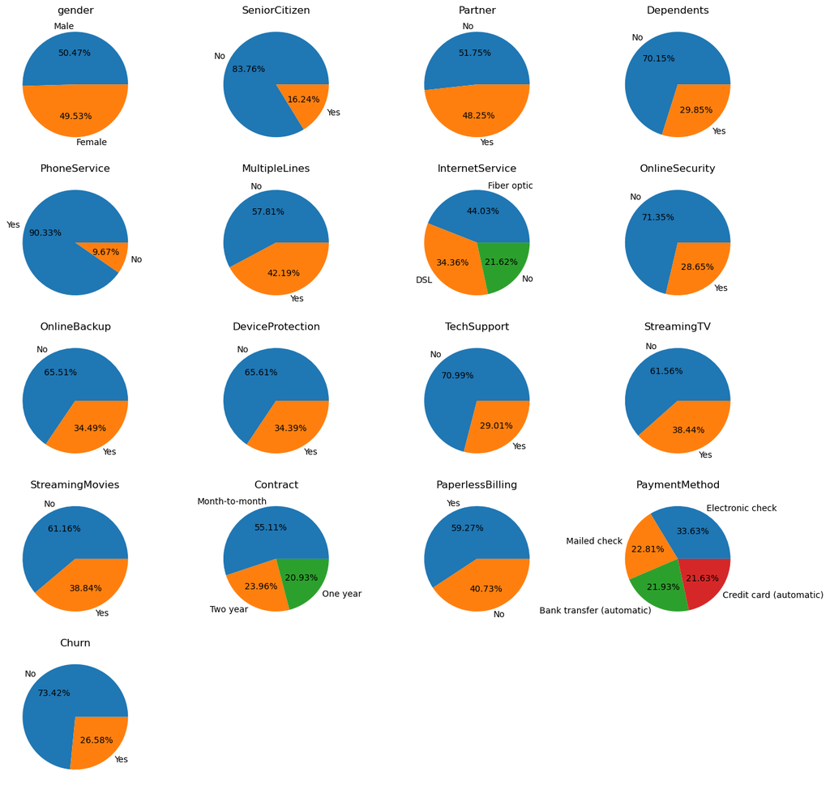

```python
df_categorical = df_churn.select_dtypes(['object'])
df_categorical.drop("customerID", axis=1, inplace=True)
plot_pie_chart(df_categorical)
```

#### D. Share insights for Q2.c. [2 Marks]

- Almost half of the customers are Male and half of them are Female
- 16% of the customers are senior citizens and 84% are not senior citizens
- 48% of the customers have partners and and 52% of the customers don't have partners
- 70% of the customers don't have dependents and 30% dependents have dependents
- 90% of the customers have the phone service and 10% don't have phone service
- 42% of the customers have multiple lines
- 44% of the customers have Fiber Optic internet service, 34% have DSL and 21% have no internet service
- 71% of the customers have not opted for Online Security
- 65% of the customers have not opted for Online backup and Device Protection
- 71% of the customers have not opted for Tech Support
- 62% of the customers have not opted for TV Streaming and Movies Streaming
- 55% of the customers are on month to month contract, 21% are on one-year contract and 24% are on two year contract
- 60% of the customers have opted for Paperless Billing
- 33% of the customers make payment by electronic check, 22% by Mailed check, 21% by Credit card and 22% by Bank transfer
- There is 26% customer churn

#### E. Encode all the appropriate Categorical features with the best suitable approach. [2 Marks]

- Using label encoding for gender, SeniorCitizen, Partner, Dependents, PhoneService, MultipleLines, OnlineSecurity, OnlineBackup, DeviceProtection, TechSupport, StreamingTV, StreamingMovies, PaperlessBilling, Churn
- For column PaymentMethod options seems independent and also values cannot be classified as 0 and 1. In the dataset, we can use normalisation for other columns to restrict all values between 0 and 1 to have all columns as equal weightage
- For columns InternetService and Contract, there is ordinality in the values. Let's dive in more.
  - In Contract, 2 year is the longest and Month-to-month is shortest. As per the correlation matrix, it is less likely for the customer with long term contract to Churn. So, let's do label encoding for Contract
  - Similarly for InternetService, No means customer doesn't have internet service. DSL means the customer has the internet service but it is not fastest and it is older technology. Fiber means customer has the fastest and latest internet technology. So, let's do label encoding for the InternetService

```python
replaceStruct = {
                    "gender": {"Female": 0, "Male": 1},
                    "SeniorCitizen": {"No": 0, "Yes": 1},
                    "Partner": {"No": 0, "Yes": 1},
                    "Dependents": {"No": 0, "Yes": 1},
                    "PhoneService": {"No": 0, "Yes": 1},
                    "MultipleLines": {"No": 0, "Yes": 1},
                    "OnlineSecurity": {"No": 0, "Yes": 1},
                    "OnlineBackup": {"No": 0, "Yes": 1},
                    "DeviceProtection": {"No": 0, "Yes": 1},
                    "TechSupport": {"No": 0, "Yes": 1},
                    "StreamingTV": {"No": 0, "Yes": 1},
                    "StreamingMovies": {"No": 0, "Yes": 1},
                    "PaperlessBilling": {"No": 0, "Yes": 1},
                    "Churn": {"No": 0, "Yes": 1},
                    "Contract": {"Two year": 2, "One year": 1, "Month-to-month": 0},
                    "InternetService": {"No": 0, "DSL": 1, "Fiber optic": 2}
                }
oneHotCols = ["PaymentMethod"]
```

```python
df_churn_encoded=df_churn.replace(replaceStruct)
df_churn_encoded=pd.get_dummies(df_churn_encoded, columns=oneHotCols, dtype=int)
df_churn_encoded.head(10)
```

|  | customerID | gender | SeniorCitizen | Partner | Dependents | tenure | PhoneService | MultipleLines | InternetService | OnlineSecurity | ... | StreamingMovies | Contract | PaperlessBilling | MonthlyCharges | TotalCharges | Churn | PaymentMethod_Bank transfer (automatic) | PaymentMethod_Credit card (automatic) | PaymentMethod_Electronic check | PaymentMethod_Mailed check |
| --- | --- | --- | --- | --- | --- | --- | --- | --- | --- | --- | --- | --- | --- | --- | --- | --- | --- | --- | --- | --- | --- |
| 0 | 7590-VHVEG | 0 | 0 | 1 | 0 | 1 | 0 | 0 | 1 | 0 | ... | 0 | 0 | 1 | 29.85 | 29.85 | 0 | 0 | 0 | 1 | 0 |
| 1 | 5575-GNVDE | 1 | 0 | 0 | 0 | 34 | 1 | 0 | 1 | 1 | ... | 0 | 1 | 0 | 56.95 | 1889.50 | 0 | 0 | 0 | 0 | 1 |
| 2 | 3668-QPYBK | 1 | 0 | 0 | 0 | 2 | 1 | 0 | 1 | 1 | ... | 0 | 0 | 1 | 53.85 | 108.15 | 1 | 0 | 0 | 0 | 1 |
| 3 | 7795-CFOCW | 1 | 0 | 0 | 0 | 45 | 0 | 0 | 1 | 1 | ... | 0 | 1 | 0 | 42.30 | 1840.75 | 0 | 1 | 0 | 0 | 0 |
| 4 | 9237-HQITU | 0 | 0 | 0 | 0 | 2 | 1 | 0 | 2 | 0 | ... | 0 | 0 | 1 | 70.70 | 151.65 | 1 | 0 | 0 | 1 | 0 |
| 5 | 9305-CDSKC | 0 | 0 | 0 | 0 | 8 | 1 | 1 | 2 | 0 | ... | 1 | 0 | 1 | 99.65 | 820.50 | 1 | 0 | 0 | 1 | 0 |
| 6 | 1452-KIOVK | 1 | 0 | 0 | 1 | 22 | 1 | 1 | 2 | 0 | ... | 0 | 0 | 1 | 89.10 | 1949.40 | 0 | 0 | 1 | 0 | 0 |
| 7 | 6713-OKOMC | 0 | 0 | 0 | 0 | 10 | 0 | 0 | 1 | 1 | ... | 0 | 0 | 0 | 29.75 | 301.90 | 0 | 0 | 0 | 0 | 1 |
| 8 | 7892-POOKP | 0 | 0 | 1 | 0 | 28 | 1 | 1 | 2 | 0 | ... | 1 | 0 | 1 | 104.80 | 3046.05 | 1 | 0 | 0 | 1 | 0 |
| 9 | 6388-TABGU | 1 | 0 | 0 | 1 | 62 | 1 | 0 | 1 | 1 | ... | 0 | 1 | 0 | 56.15 | 3487.95 | 0 | 1 | 0 | 0 | 0 |

10 rows × 24 columns

```python
df_churn_encoded.dtypes
```

```
customerID                                  object
gender                                       int64
SeniorCitizen                                int64
Partner                                      int64
Dependents                                   int64
tenure                                       int64
PhoneService                                 int64
MultipleLines                                int64
InternetService                              int64
OnlineSecurity                               int64
OnlineBackup                                 int64
DeviceProtection                             int64
TechSupport                                  int64
StreamingTV                                  int64
StreamingMovies                              int64
Contract                                     int64
PaperlessBilling                             int64
MonthlyCharges                             float64
TotalCharges                               float64
Churn                                        int64
PaymentMethod_Bank transfer (automatic)      int64
PaymentMethod_Credit card (automatic)        int64
PaymentMethod_Electronic check               int64
PaymentMethod_Mailed check                   int64
dtype: object
```

##### Drop 'customerID' column as it is not required for model building and testing

```python
df_churn_encoded.drop('customerID', axis=1, inplace=True)
```

#### Split independent and dependent variables in the data

```python
X = df_churn_encoded.drop("Churn", axis=1)
y = df_churn_encoded['Churn']
```

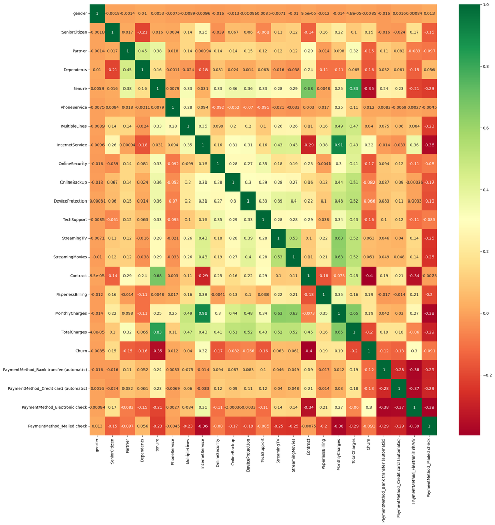

```python
#get correlations of each features in dataset
corrmat = df_churn_encoded.corr()
top_corr_features = corrmat.index
plt.figure(figsize=(20,20))
#plot heat map
g=sns.heatmap(df_churn_encoded[top_corr_features].corr(),annot=True,cmap="RdYlGn")
```

#### F. Split the data into 80% train and 20% test. [1 Marks]

```python
X_train, X_test, y_train, y_test = train_test_split(X, y, test_size=.20, random_state=1, stratify=y)
```

#### G. Normalize/Standardize the data with the best suitable approach. [2 Marks]

Using MinMaxScaler here since most of the columns have values between 0 and 1. This will help bring all the columns to common weight

```python
# Fit and transform training data

scaler = MinMaxScaler()
d = scaler.fit_transform(X_train)
X_train_norm = pd.DataFrame(d, columns=X_train.columns)
X_train_norm
```

|  | gender | SeniorCitizen | Partner | Dependents | tenure | PhoneService | MultipleLines | InternetService | OnlineSecurity | OnlineBackup | ... | StreamingTV | StreamingMovies | Contract | PaperlessBilling | MonthlyCharges | TotalCharges | PaymentMethod_Bank transfer (automatic) | PaymentMethod_Credit card (automatic) | PaymentMethod_Electronic check | PaymentMethod_Mailed check |
| --- | --- | --- | --- | --- | --- | --- | --- | --- | --- | --- | --- | --- | --- | --- | --- | --- | --- | --- | --- | --- | --- |
| 0 | 1.0 | 0.0 | 1.0 | 0.0 | 0.774648 | 1.0 | 0.0 | 1.0 | 0.0 | 0.0 | ... | 0.0 | 1.0 | 0.5 | 1.0 | 0.624004 | 0.523736 | 0.0 | 0.0 | 1.0 | 0.0 |
| 1 | 1.0 | 0.0 | 1.0 | 0.0 | 0.985915 | 1.0 | 1.0 | 0.5 | 1.0 | 1.0 | ... | 0.0 | 1.0 | 1.0 | 1.0 | 0.616036 | 0.642349 | 0.0 | 0.0 | 0.0 | 1.0 |
| 2 | 0.0 | 1.0 | 1.0 | 1.0 | 0.915493 | 1.0 | 1.0 | 1.0 | 1.0 | 1.0 | ... | 1.0 | 1.0 | 0.5 | 1.0 | 0.919821 | 0.829916 | 0.0 | 1.0 | 0.0 | 0.0 |
| 3 | 1.0 | 0.0 | 0.0 | 1.0 | 0.000000 | 1.0 | 0.0 | 0.0 | 0.0 | 0.0 | ... | 0.0 | 0.0 | 0.0 | 0.0 | 0.012948 | 0.000087 | 0.0 | 0.0 | 0.0 | 1.0 |
| 4 | 0.0 | 1.0 | 1.0 | 0.0 | 0.422535 | 0.0 | 0.0 | 0.5 | 1.0 | 1.0 | ... | 0.0 | 1.0 | 0.5 | 1.0 | 0.320219 | 0.180164 | 0.0 | 1.0 | 0.0 | 0.0 |
| ... | ... | ... | ... | ... | ... | ... | ... | ... | ... | ... | ... | ... | ... | ... | ... | ... | ... | ... | ... | ... | ... |
| 5620 | 1.0 | 0.0 | 0.0 | 0.0 | 0.000000 | 1.0 | 0.0 | 0.0 | 0.0 | 0.0 | ... | 0.0 | 0.0 | 0.0 | 0.0 | 0.019422 | 0.000162 | 0.0 | 0.0 | 0.0 | 1.0 |
| 5621 | 1.0 | 0.0 | 1.0 | 1.0 | 0.957746 | 1.0 | 1.0 | 1.0 | 1.0 | 1.0 | ... | 1.0 | 1.0 | 1.0 | 1.0 | 0.957171 | 0.882414 | 1.0 | 0.0 | 0.0 | 0.0 |
| 5622 | 1.0 | 1.0 | 1.0 | 0.0 | 0.816901 | 0.0 | 0.0 | 0.5 | 0.0 | 1.0 | ... | 1.0 | 1.0 | 0.0 | 1.0 | 0.318725 | 0.343717 | 0.0 | 0.0 | 1.0 | 0.0 |
| 5623 | 1.0 | 0.0 | 0.0 | 0.0 | 0.309859 | 1.0 | 1.0 | 1.0 | 0.0 | 0.0 | ... | 0.0 | 0.0 | 0.0 | 1.0 | 0.564741 | 0.195205 | 0.0 | 0.0 | 1.0 | 0.0 |
| 5624 | 1.0 | 0.0 | 1.0 | 1.0 | 0.676056 | 1.0 | 1.0 | 1.0 | 0.0 | 0.0 | ... | 1.0 | 0.0 | 0.0 | 0.0 | 0.659861 | 0.488813 | 0.0 | 0.0 | 1.0 | 0.0 |

5625 rows × 22 columns

```python
X_train_norm.describe()
```

|  | gender | SeniorCitizen | Partner | Dependents | tenure | PhoneService | MultipleLines | InternetService | OnlineSecurity | OnlineBackup | ... | StreamingTV | StreamingMovies | Contract | PaperlessBilling | MonthlyCharges | TotalCharges | PaymentMethod_Bank transfer (automatic) | PaymentMethod_Credit card (automatic) | PaymentMethod_Electronic check | PaymentMethod_Mailed check |
| --- | --- | --- | --- | --- | --- | --- | --- | --- | --- | --- | --- | --- | --- | --- | --- | --- | --- | --- | --- | --- | --- |
| count | 5625.000000 | 5625.000000 | 5625.000000 | 5625.000000 | 5625.000000 | 5625.000000 | 5625.000000 | 5625.000000 | 5625.000000 | 5625.000000 | ... | 5625.000000 | 5625.000000 | 5625.000000 | 5625.000000 | 5625.000000 | 5625.000000 | 5625.000000 | 5625.000000 | 5625.000000 | 5625.000000 |
| mean | 0.505600 | 0.159822 | 0.481422 | 0.298844 | 0.442103 | 0.903822 | 0.422578 | 0.611822 | 0.283200 | 0.345956 | ... | 0.387022 | 0.390578 | 0.345689 | 0.590933 | 0.464104 | 0.261013 | 0.219022 | 0.216711 | 0.335467 | 0.228800 |
| std | 0.500013 | 0.366474 | 0.499699 | 0.457792 | 0.345646 | 0.294861 | 0.494013 | 0.389830 | 0.450593 | 0.475721 | ... | 0.487112 | 0.487923 | 0.417449 | 0.491705 | 0.300294 | 0.261330 | 0.413620 | 0.412041 | 0.472195 | 0.420098 |
| min | 0.000000 | 0.000000 | 0.000000 | 0.000000 | 0.000000 | 0.000000 | 0.000000 | 0.000000 | 0.000000 | 0.000000 | ... | 0.000000 | 0.000000 | 0.000000 | 0.000000 | 0.000000 | 0.000000 | 0.000000 | 0.000000 | 0.000000 | 0.000000 |
| 25% | 0.000000 | 0.000000 | 0.000000 | 0.000000 | 0.112676 | 1.000000 | 0.000000 | 0.500000 | 0.000000 | 0.000000 | ... | 0.000000 | 0.000000 | 0.000000 | 0.000000 | 0.171315 | 0.043942 | 0.000000 | 0.000000 | 0.000000 | 0.000000 |
| 50% | 1.000000 | 0.000000 | 0.000000 | 0.000000 | 0.394366 | 1.000000 | 0.000000 | 0.500000 | 0.000000 | 0.000000 | ... | 0.000000 | 0.000000 | 0.000000 | 1.000000 | 0.520418 | 0.158920 | 0.000000 | 0.000000 | 0.000000 | 0.000000 |
| 75% | 1.000000 | 0.000000 | 1.000000 | 1.000000 | 0.774648 | 1.000000 | 1.000000 | 1.000000 | 1.000000 | 1.000000 | ... | 1.000000 | 1.000000 | 0.500000 | 1.000000 | 0.713645 | 0.434295 | 0.000000 | 0.000000 | 1.000000 | 0.000000 |
| max | 1.000000 | 1.000000 | 1.000000 | 1.000000 | 1.000000 | 1.000000 | 1.000000 | 1.000000 | 1.000000 | 1.000000 | ... | 1.000000 | 1.000000 | 1.000000 | 1.000000 | 1.000000 | 1.000000 | 1.000000 | 1.000000 | 1.000000 | 1.000000 |

8 rows × 22 columns

```python
# Transform testing data

d = scaler.transform(X_test)
X_test_norm = pd.DataFrame(d, columns=X_test.columns)
X_test_norm
```

|  | gender | SeniorCitizen | Partner | Dependents | tenure | PhoneService | MultipleLines | InternetService | OnlineSecurity | OnlineBackup | ... | StreamingTV | StreamingMovies | Contract | PaperlessBilling | MonthlyCharges | TotalCharges | PaymentMethod_Bank transfer (automatic) | PaymentMethod_Credit card (automatic) | PaymentMethod_Electronic check | PaymentMethod_Mailed check |
| --- | --- | --- | --- | --- | --- | --- | --- | --- | --- | --- | --- | --- | --- | --- | --- | --- | --- | --- | --- | --- | --- |
| 0 | 0.0 | 1.0 | 0.0 | 0.0 | 0.887324 | 0.0 | 0.0 | 0.5 | 0.0 | 1.0 | ... | 1.0 | 0.0 | 0.0 | 1.0 | 0.254980 | 0.315278 | 0.0 | 0.0 | 1.0 | 0.0 |
| 1 | 1.0 | 0.0 | 1.0 | 0.0 | 0.098592 | 1.0 | 0.0 | 0.0 | 0.0 | 0.0 | ... | 0.0 | 0.0 | 0.0 | 1.0 | 0.012948 | 0.016426 | 1.0 | 0.0 | 0.0 | 0.0 |
| 2 | 0.0 | 0.0 | 1.0 | 1.0 | 0.478873 | 1.0 | 1.0 | 0.0 | 0.0 | 0.0 | ... | 0.0 | 0.0 | 1.0 | 1.0 | 0.071215 | 0.107431 | 0.0 | 1.0 | 0.0 | 0.0 |
| 3 | 0.0 | 0.0 | 1.0 | 0.0 | 0.690141 | 1.0 | 1.0 | 1.0 | 1.0 | 1.0 | ... | 1.0 | 1.0 | 0.0 | 1.0 | 0.910359 | 0.621625 | 1.0 | 0.0 | 0.0 | 0.0 |
| 4 | 1.0 | 0.0 | 0.0 | 1.0 | 0.042254 | 1.0 | 1.0 | 1.0 | 0.0 | 1.0 | ... | 1.0 | 1.0 | 0.0 | 1.0 | 0.831175 | 0.039897 | 0.0 | 0.0 | 1.0 | 0.0 |
| ... | ... | ... | ... | ... | ... | ... | ... | ... | ... | ... | ... | ... | ... | ... | ... | ... | ... | ... | ... | ... | ... |
| 1402 | 1.0 | 0.0 | 0.0 | 0.0 | 0.014085 | 1.0 | 0.0 | 0.5 | 0.0 | 0.0 | ... | 1.0 | 1.0 | 0.0 | 0.0 | 0.518426 | 0.013109 | 0.0 | 0.0 | 1.0 | 0.0 |
| 1403 | 0.0 | 0.0 | 1.0 | 0.0 | 0.647887 | 1.0 | 1.0 | 1.0 | 0.0 | 0.0 | ... | 1.0 | 1.0 | 0.0 | 1.0 | 0.819223 | 0.540999 | 0.0 | 0.0 | 1.0 | 0.0 |
| 1404 | 0.0 | 1.0 | 1.0 | 0.0 | 0.760563 | 1.0 | 1.0 | 0.5 | 0.0 | 0.0 | ... | 0.0 | 0.0 | 0.0 | 0.0 | 0.332669 | 0.325381 | 1.0 | 0.0 | 0.0 | 0.0 |
| 1405 | 1.0 | 0.0 | 0.0 | 0.0 | 0.267606 | 1.0 | 0.0 | 1.0 | 0.0 | 0.0 | ... | 0.0 | 0.0 | 0.0 | 0.0 | 0.520916 | 0.170177 | 0.0 | 1.0 | 0.0 | 0.0 |
| 1406 | 0.0 | 0.0 | 0.0 | 0.0 | 0.098592 | 1.0 | 0.0 | 0.5 | 1.0 | 0.0 | ... | 1.0 | 0.0 | 0.0 | 1.0 | 0.415837 | 0.054114 | 0.0 | 0.0 | 1.0 | 0.0 |

1407 rows × 22 columns

```python
X_test_norm.describe()
```

|  | gender | SeniorCitizen | Partner | Dependents | tenure | PhoneService | MultipleLines | InternetService | OnlineSecurity | OnlineBackup | ... | StreamingTV | StreamingMovies | Contract | PaperlessBilling | MonthlyCharges | TotalCharges | PaymentMethod_Bank transfer (automatic) | PaymentMethod_Credit card (automatic) | PaymentMethod_Electronic check | PaymentMethod_Mailed check |
| --- | --- | --- | --- | --- | --- | --- | --- | --- | --- | --- | --- | --- | --- | --- | --- | --- | --- | --- | --- | --- | --- |
| count | 1407.000000 | 1407.000000 | 1407.000000 | 1407.000000 | 1407.000000 | 1407.000000 | 1407.000000 | 1407.000000 | 1407.000000 | 1407.000000 | ... | 1407.000000 | 1407.000000 | 1407.000000 | 1407.000000 | 1407.000000 | 1407.000000 | 1407.000000 | 1407.000000 | 1407.000000 | 1407.000000 |
| mean | 0.501066 | 0.172708 | 0.486851 | 0.297086 | 0.444388 | 0.901208 | 0.419332 | 0.613006 | 0.299929 | 0.340441 | ... | 0.373845 | 0.379531 | 0.338664 | 0.599858 | 0.461723 | 0.262491 | 0.220327 | 0.214641 | 0.339730 | 0.225302 |
| std | 0.500177 | 0.378129 | 0.500005 | 0.457137 | 0.346073 | 0.298488 | 0.493625 | 0.387420 | 0.458389 | 0.474026 | ... | 0.483995 | 0.485443 | 0.412618 | 0.490101 | 0.297215 | 0.262622 | 0.414614 | 0.410719 | 0.473786 | 0.417930 |
| min | 0.000000 | 0.000000 | 0.000000 | 0.000000 | 0.000000 | 0.000000 | 0.000000 | 0.000000 | 0.000000 | 0.000000 | ... | 0.000000 | 0.000000 | 0.000000 | 0.000000 | 0.005478 | 0.000046 | 0.000000 | 0.000000 | 0.000000 | 0.000000 |
| 25% | 0.000000 | 0.000000 | 0.000000 | 0.000000 | 0.098592 | 1.000000 | 0.000000 | 0.500000 | 0.000000 | 0.000000 | ... | 0.000000 | 0.000000 | 0.000000 | 0.000000 | 0.200697 | 0.045503 | 0.000000 | 0.000000 | 0.000000 | 0.000000 |
| 50% | 1.000000 | 0.000000 | 0.000000 | 0.000000 | 0.394366 | 1.000000 | 0.000000 | 0.500000 | 0.000000 | 0.000000 | ... | 0.000000 | 0.000000 | 0.000000 | 1.000000 | 0.516932 | 0.160674 | 0.000000 | 0.000000 | 0.000000 | 0.000000 |
| 75% | 1.000000 | 0.000000 | 1.000000 | 1.000000 | 0.760563 | 1.000000 | 1.000000 | 1.000000 | 1.000000 | 1.000000 | ... | 1.000000 | 1.000000 | 0.500000 | 1.000000 | 0.713147 | 0.441406 | 0.000000 | 0.000000 | 1.000000 | 0.000000 |
| max | 1.000000 | 1.000000 | 1.000000 | 1.000000 | 1.000000 | 1.000000 | 1.000000 | 1.000000 | 1.000000 | 1.000000 | ... | 1.000000 | 1.000000 | 1.000000 | 1.000000 | 1.000996 | 0.998575 | 1.000000 | 1.000000 | 1.000000 | 1.000000 |

8 rows × 22 columns

#### 3. Model building and performance improvement : [40 Marks]

#### A. Train a model using Decision tree and check the performance of the model on train and test data ( 4 marks )

```python
dTree = DecisionTreeClassifier(criterion = 'gini', random_state=1)
dTree.fit(X_train_norm, y_train)
```

```
DecisionTreeClassifier(random_state=1)
```

```python
dTree.score(X_test_norm, y_test)
print(dTree.score(X_train_norm, y_train))
print(dTree.score(X_test_norm, y_test))
```

```
0.9971555555555556
0.7114427860696517
```

#### Visualising the Decision Tree

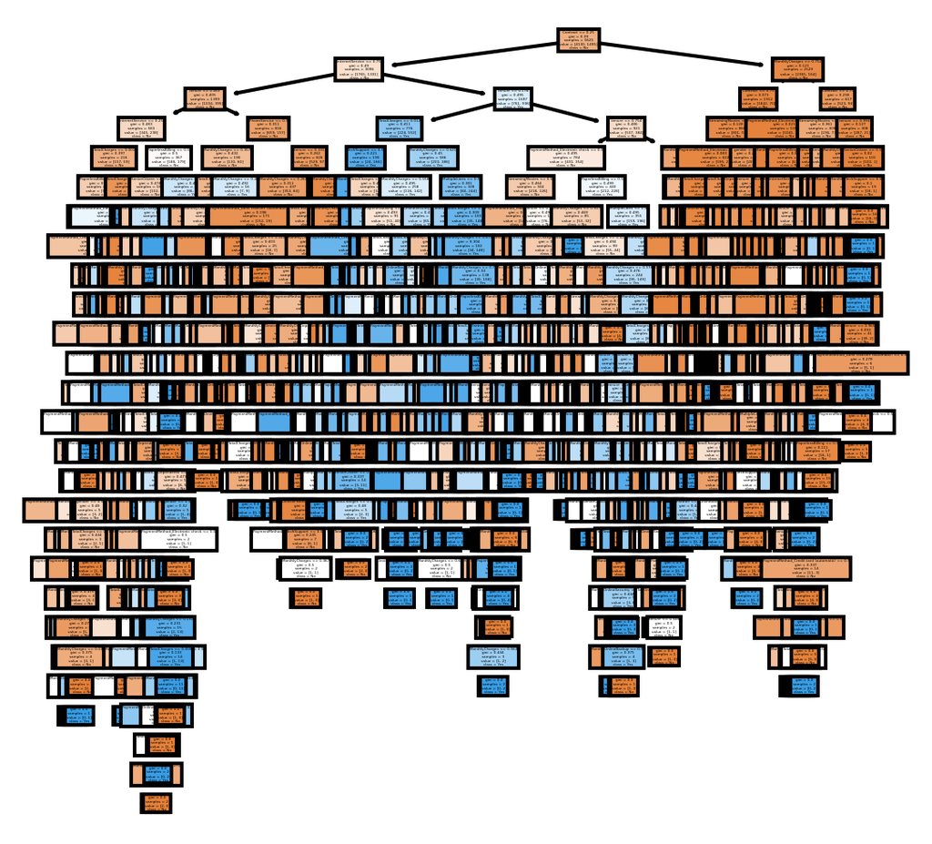

```python
fn = list(X_train)
cn = ['No', 'Yes']
fig, axes = plt.subplots(nrows = 1,ncols = 1,figsize = (4, 4), dpi=300)
plot_tree(dTree, feature_names = fn, class_names=cn, filled = True)

fig.savefig('tree.png')
```

```python
# Importance of each features in percentage

print(pd.DataFrame(dTree.feature_importances_, columns = ["Importance"], index = X_train.columns).sort_values("Importance", ascending=False))
```

```
                                         Importance
MonthlyCharges                             0.224846
TotalCharges                               0.185115
Contract                                   0.175803
tenure                                     0.120616
InternetService                            0.056952
gender                                     0.024906
Partner                                    0.023131
PaperlessBilling                           0.020544
MultipleLines                              0.017456
SeniorCitizen                              0.017089
Dependents                                 0.015514
TechSupport                                0.015503
OnlineBackup                               0.014992
PaymentMethod_Electronic check             0.014433
OnlineSecurity                             0.012880
StreamingMovies                            0.012457
DeviceProtection                           0.011378
PaymentMethod_Credit card (automatic)      0.010333
PaymentMethod_Bank transfer (automatic)    0.010241
PaymentMethod_Mailed check                 0.007024
PhoneService                               0.005402
StreamingTV                                0.003382
```

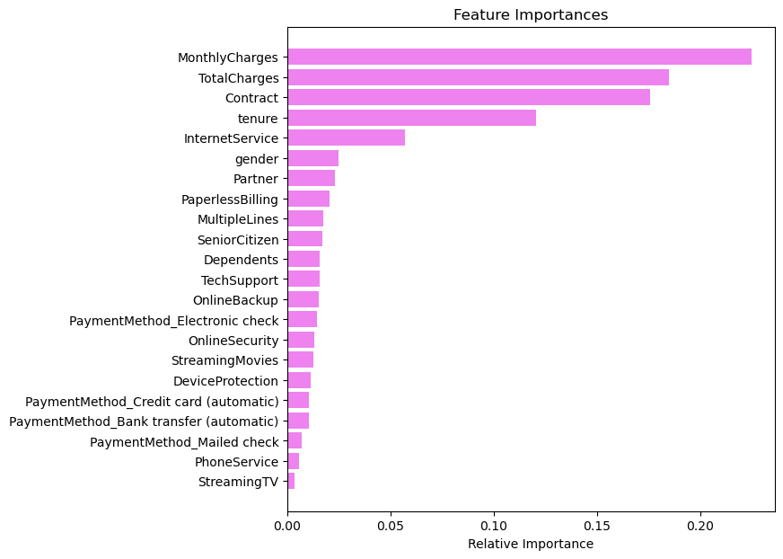

```python
importances = dTree.feature_importances_
indices = np.argsort(importances)
feature_names = list(X.columns)

plt.figure(figsize=(7,7))
plt.title("Feature Importances")
plt.barh(range(len(indices)), importances[indices], color='violet')
plt.yticks(range(len(indices)), [feature_names[i] for i in indices])
plt.xlabel('Relative Importance')
```

```
0.7114427860696517
```

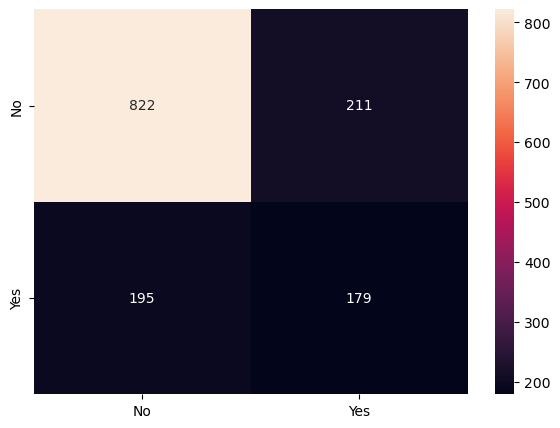

```python
print(dTree.score(X_test_norm , y_test))
y_predict = dTree.predict(X_test_norm)

cm = confusion_matrix(y_test, y_predict, labels=[0, 1])

df_cm = pd.DataFrame(cm, index = [i for i in ["No","Yes"]],
                  columns = [i for i in ["No","Yes"]])
plt.figure(figsize = (7,5))
sns.heatmap(df_cm, annot=True ,fmt='g');
```

```python
print(classification_report(y_test, y_predict))
```

```
              precision    recall  f1-score   support

           0       0.81      0.80      0.80      1033
           1       0.46      0.48      0.47       374

    accuracy                           0.71      1407
   macro avg       0.63      0.64      0.64      1407
weighted avg       0.72      0.71      0.71      1407
```

#### As we can see there is high degree of overfitting in the model due to which the test accuracy drops drastically

#### Regularisation: Let's prune for maximum depth of the decision tree to 5 and check the accuracy

```python
dTree_regularised = DecisionTreeClassifier(criterion = 'gini', random_state=1, max_depth=5)
dTree_regularised.fit(X_train_norm, y_train)
```

```
DecisionTreeClassifier(max_depth=5, random_state=1)
```

```python
print(dTree_regularised.score(X_train_norm, y_train))
print(dTree_regularised.score(X_test_norm, y_test))
```

```
0.8010666666666667
0.7825159914712153
```

Though there is decrease in accuracy on the training data, We see that accuracy on the test data has improved.

#### Visualising the regularised tree

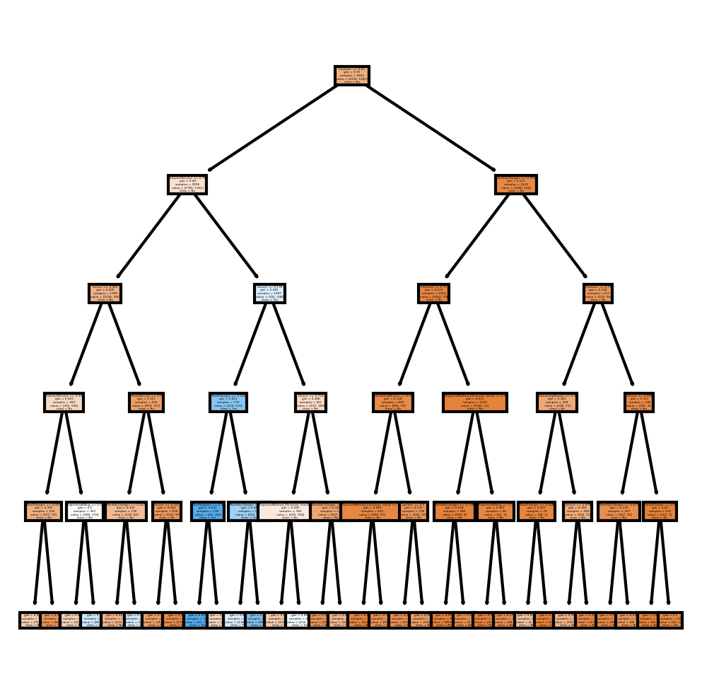

```python
fn = list(X_train)
cn = ['No', 'Yes']
fig, axes = plt.subplots(nrows = 1,ncols = 1,figsize = (4, 4), dpi=300)
plot_tree(dTree_regularised, feature_names = fn, class_names=cn, filled = True)

fig.savefig('tree.png')
```

```python
# Importance of each features in percentage

print(pd.DataFrame(dTree_regularised.feature_importances_, columns = ["Importance"], index = X_train.columns).sort_values("Importance", ascending=False))
```

```
                                         Importance
Contract                                   0.537646
tenure                                     0.173967
InternetService                            0.173650
MonthlyCharges                             0.040113
TotalCharges                               0.028308
PaymentMethod_Electronic check             0.014174
PhoneService                               0.010588
PaperlessBilling                           0.009321
StreamingMovies                            0.007665
TechSupport                                0.003235
gender                                     0.001212
SeniorCitizen                              0.000120
StreamingTV                                0.000000
DeviceProtection                           0.000000
OnlineBackup                               0.000000
OnlineSecurity                             0.000000
MultipleLines                              0.000000
Dependents                                 0.000000
PaymentMethod_Bank transfer (automatic)    0.000000
PaymentMethod_Credit card (automatic)      0.000000
Partner                                    0.000000
PaymentMethod_Mailed check                 0.000000
```

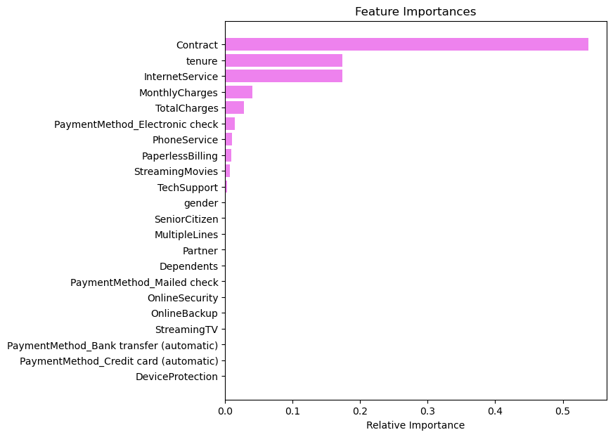

```python
importances = dTree_regularised.feature_importances_
indices = np.argsort(importances)
feature_names = list(X.columns)

plt.figure(figsize=(7,7))
plt.title("Feature Importances")
plt.barh(range(len(indices)), importances[indices], color='violet')
plt.yticks(range(len(indices)), [feature_names[i] for i in indices])
plt.xlabel('Relative Importance')
```

```
0.8010666666666667
0.7825159914712153
```

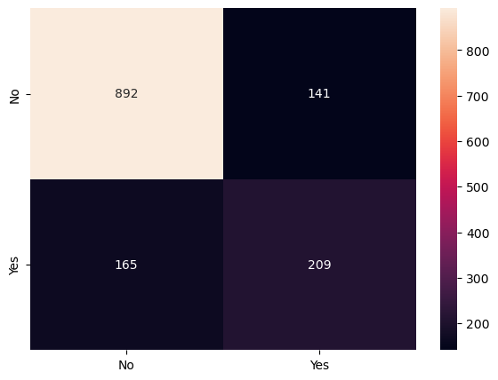

```python
print(dTree_regularised.score(X_train_norm , y_train))
print(dTree_regularised.score(X_test_norm , y_test))
y_predict = dTree_regularised.predict(X_test_norm)

cm = confusion_matrix(y_test, y_predict, labels=[0, 1])

df_cm = pd.DataFrame(cm, index = [i for i in ["No","Yes"]],
                  columns = [i for i in ["No","Yes"]])
plt.figure(figsize = (7,5))
sns.heatmap(df_cm, annot=True ,fmt='g');
```

```python
print(classification_report(y_test,y_predict))
```

```
              precision    recall  f1-score   support

           0       0.84      0.86      0.85      1033
           1       0.60      0.56      0.58       374

    accuracy                           0.78      1407
   macro avg       0.72      0.71      0.72      1407
weighted avg       0.78      0.78      0.78      1407
```

#### B. Use grid search and improve the performance of the Decision tree model , check the performance of the model on train and test data , provide the differences observed in performance in Q3.a and Q3.b ( 5 marks )

```python
#Hyper-parameters to tune for the decision treee

params = {
    'max_depth': [2, 3, 5, 10, 20],
    'min_samples_leaf': [5, 10, 20, 50, 100],
    'criterion': ["gini", "entropy"]
}
```

```python
# Instantiate the grid search model
grid_search = GridSearchCV(estimator=dTree,
                           param_grid=params,
                           cv=5, scoring = metrics.make_scorer(metrics.recall_score))
```

```python
grid_search.fit(X_train_norm, y_train)
```

```
GridSearchCV(cv=5, estimator=DecisionTreeClassifier(random_state=1),
             param_grid={'criterion': ['gini', 'entropy'],
                         'max_depth': [2, 3, 5, 10, 20],
                         'min_samples_leaf': [5, 10, 20, 50, 100]},
             scoring=make_scorer(recall_score))
```

```python
dTree_gridsearch = grid_search.best_estimator_
dTree_gridsearch
```

```
DecisionTreeClassifier(max_depth=2, min_samples_leaf=5, random_state=1)
```

```python
print(dTree_gridsearch.score(X_train_norm, y_train))
print(dTree_gridsearch.score(X_test_norm, y_test))
```

```
0.7653333333333333
0.7491115849324804
```

#### Visualising the tuned tree

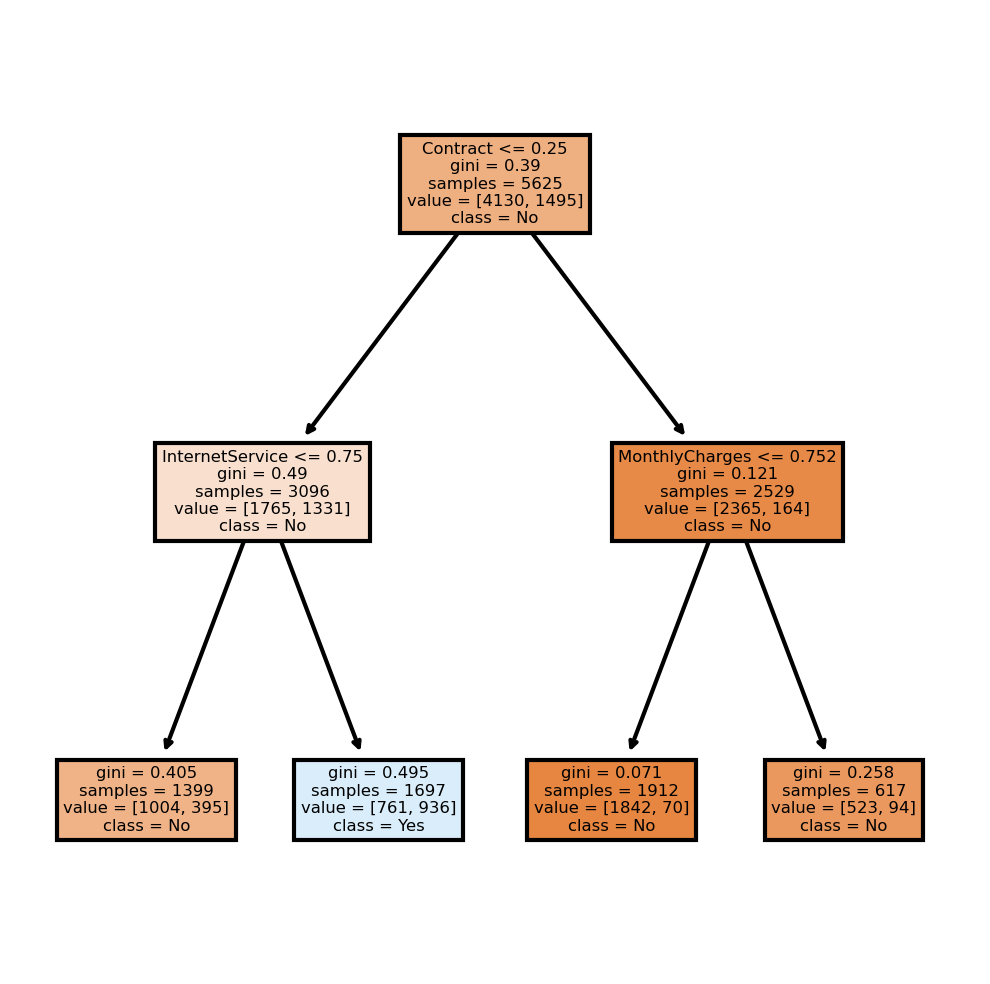

```python
fn = list(X_train)
cn = ['No', 'Yes']
fig, axes = plt.subplots(nrows = 1,ncols = 1,figsize = (4, 4), dpi=300)
plot_tree(dTree_gridsearch, feature_names = fn, class_names=cn, filled = True)

fig.savefig('tree.png')
```

```python
# Importance of each features in percentage

print(pd.DataFrame(dTree_gridsearch.feature_importances_, columns = ["Importance"], index = X_train.columns).sort_values("Importance", ascending=False))
```

```
                                         Importance
Contract                                   0.750027
InternetService                            0.224709
MonthlyCharges                             0.025264
gender                                     0.000000
StreamingTV                                0.000000
PaymentMethod_Electronic check             0.000000
PaymentMethod_Credit card (automatic)      0.000000
PaymentMethod_Bank transfer (automatic)    0.000000
TotalCharges                               0.000000
PaperlessBilling                           0.000000
StreamingMovies                            0.000000
TechSupport                                0.000000
SeniorCitizen                              0.000000
DeviceProtection                           0.000000
OnlineBackup                               0.000000
OnlineSecurity                             0.000000
MultipleLines                              0.000000
PhoneService                               0.000000
tenure                                     0.000000
Dependents                                 0.000000
Partner                                    0.000000
PaymentMethod_Mailed check                 0.000000
```

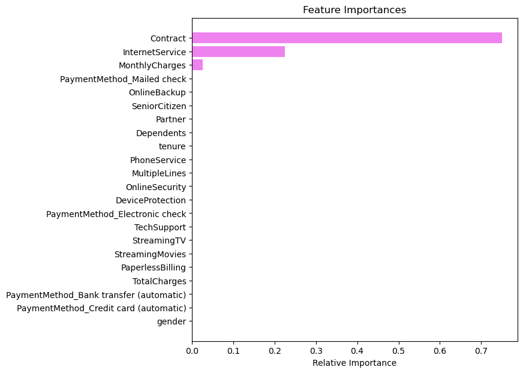

```python
importances = dTree_gridsearch.feature_importances_
indices = np.argsort(importances)
feature_names = list(X.columns)

plt.figure(figsize=(7,7))
plt.title("Feature Importances")
plt.barh(range(len(indices)), importances[indices], color='violet')
plt.yticks(range(len(indices)), [feature_names[i] for i in indices])
plt.xlabel('Relative Importance')
```

#### From the feature importance dataframe we can infer that Contract_Month-to-month, InternetService_Fiber optic and MonthlyCharges are the variables that impact Churn

```
0.7653333333333333
0.7491115849324804
```

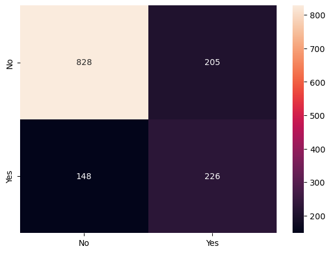

```python
print(dTree_gridsearch.score(X_train_norm , y_train))
print(dTree_gridsearch.score(X_test_norm , y_test))
y_predict = dTree_gridsearch.predict(X_test_norm)

cm = confusion_matrix(y_test, y_predict, labels=[0, 1])

df_cm = pd.DataFrame(cm, index = [i for i in ["No","Yes"]],
                  columns = [i for i in ["No","Yes"]])
plt.figure(figsize = (7,5))
sns.heatmap(df_cm, annot=True ,fmt='g');
```

```python
print(classification_report(y_test,y_predict))
```

```
              precision    recall  f1-score   support

           0       0.85      0.80      0.82      1033
           1       0.52      0.60      0.56       374

    accuracy                           0.75      1407
   macro avg       0.69      0.70      0.69      1407
weighted avg       0.76      0.75      0.75      1407
```

#### Differences observed in performance in Q3.a and Q3.b

By regularisation using pruning the DecisionTree by applying max_depth=5, we could improve the accuracy on the testing data to 78%. But the recall score of 1 was at 56%. Our goal is to find the features which affect the customer churn accurately. This means, we need to look at recall score of 1.

Also, by using the grid search, we tuned the hyper-parameters like max_depth, min_samples_leaf, criterion and found the best values. Best values are below:

- criterion='gini'
- max_depth=2
- min_samples_leaf=5

#### Conclusion :

With tuning the DecisionTree by applying GridSearch we got the best hyper parameters max_depth=2 and min_samples_leaf=5, we could predict 226 customers churn accurately out of 374, with recall of 60%. This is the best result we seen so far in the DecisionTree model. Since our goal is to predict the customer churn accurately, we will tune the model for recall and for Churn=Yes.

#### C. Train a model using Random forest and check the performance of the model on train and test data ( 4 marks )

```python
randomForest = RandomForestClassifier(random_state=1)
randomForest = randomForest.fit(X_train_norm, y_train)
```

```python
print(randomForest.score(X_train_norm, y_train))
print(randomForest.score(X_test_norm, y_test))
```

```
0.9971555555555556
0.7853589196872779
```

```python
# Importance of each features in percentage

print(pd.DataFrame(randomForest.feature_importances_, columns = ["Importance"], index = X_train.columns).sort_values("Importance", ascending=False))
```

```
                                         Importance
TotalCharges                               0.186452
MonthlyCharges                             0.177231
tenure                                     0.161688
Contract                                   0.086813
InternetService                            0.050097
PaymentMethod_Electronic check             0.034149
gender                                     0.029009
PaperlessBilling                           0.028050
Partner                                    0.023232
OnlineBackup                               0.022230
OnlineSecurity                             0.021575
TechSupport                                0.020335
SeniorCitizen                              0.020283
MultipleLines                              0.020269
Dependents                                 0.019685
DeviceProtection                           0.019070
StreamingMovies                            0.018931
StreamingTV                                0.018360
PaymentMethod_Bank transfer (automatic)    0.011839
PaymentMethod_Credit card (automatic)      0.011756
PaymentMethod_Mailed check                 0.011182
PhoneService                               0.007765
```

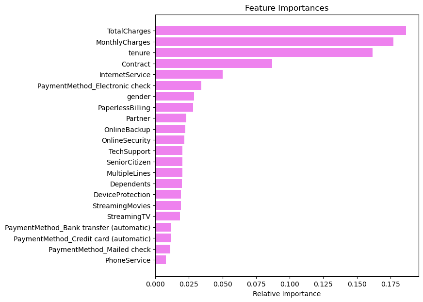

```python
importances = randomForest.feature_importances_
indices = np.argsort(importances)
feature_names = list(X.columns)

plt.figure(figsize=(7,7))
plt.title("Feature Importances")
plt.barh(range(len(indices)), importances[indices], color='violet')
plt.yticks(range(len(indices)), [feature_names[i] for i in indices])
plt.xlabel('Relative Importance')
```

```
0.7853589196872779
```

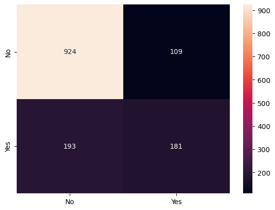

```python
print(randomForest.score(X_test_norm , y_test))
y_predict = randomForest.predict(X_test_norm)

cm = confusion_matrix(y_test, y_predict, labels=[0, 1])

df_cm = pd.DataFrame(cm, index = [i for i in ["No","Yes"]],
                  columns = [i for i in ["No","Yes"]])
plt.figure(figsize = (7,5))
sns.heatmap(df_cm, annot=True ,fmt='g');
```

```python
print(classification_report(y_test,y_predict))
```

```
              precision    recall  f1-score   support

           0       0.83      0.89      0.86      1033
           1       0.62      0.48      0.55       374

    accuracy                           0.79      1407
   macro avg       0.73      0.69      0.70      1407
weighted avg       0.77      0.79      0.78      1407
```

Even in Random Forest, we could see that model was overfitting the training data. Accuracy on training data is 99.7% and accuracy on testing data is 78.6%. Also, recall score of 1 is 48% which is pretty low for identifying the customer churn

#### D. Use grid search and improve the performance of the Random tree model , check the performance of the model on train and test data , provide the differences observed in performance in Q3.c and Q3.d ( 5 marks )

```python
rf_params = {
    'n_estimators': [25, 50, 100, 150],
    'max_depth': np.arange(2, 5),
    #'max_features': np.arange(0.2, 0.7, 1),
    #'max_samples': np.arange(0.3, 0.7, 1),
    'min_samples_leaf': np.arange(2, 5),
    'class_weight': [{0: 0.2658, 1: 0.7342}] # Chosing {0: 0.2658, 1: 0.7342} as class weights because that's the original imbalance in our data
}
```

```python
# Perform Grid Search for Random Forest
grid_search = GridSearchCV(estimator=RandomForestClassifier(random_state=1),
                              param_grid=rf_params, cv=5, scoring = metrics.make_scorer(metrics.recall_score), n_jobs=-1)
grid_search.fit(X_train_norm, y_train)
```

```
GridSearchCV(cv=5, estimator=RandomForestClassifier(random_state=1), n_jobs=-1,
             param_grid={'class_weight': [{0: 0.2658, 1: 0.7342}],
                         'max_depth': array([2, 3, 4]),
                         'min_samples_leaf': array([2, 3, 4]),
                         'n_estimators': [25, 50, 100, 150]},
             scoring=make_scorer(recall_score))
```

```python
rf_grid_search = grid_search.best_estimator_
rf_grid_search
```

```
RandomForestClassifier(class_weight={0: 0.2658, 1: 0.7342}, max_depth=2,
                       min_samples_leaf=2, random_state=1)
```

```python
print(rf_grid_search.score(X_train_norm, y_train))
print(rf_grid_search.score(X_test_norm, y_test))
```

```
0.7045333333333333
0.6950959488272921
```

```python
# Importance of each features in percentage

print(pd.DataFrame(rf_grid_search.feature_importances_, columns = ["Importance"], index = X_train.columns).sort_values("Importance", ascending=False))
```

```
                                         Importance
Contract                                   0.329744
tenure                                     0.187105
InternetService                            0.102792
PaymentMethod_Electronic check             0.100221
MonthlyCharges                             0.075695
TotalCharges                               0.071155
PaperlessBilling                           0.037903
OnlineSecurity                             0.025493
TechSupport                                0.017424
PaymentMethod_Credit card (automatic)      0.010047
SeniorCitizen                              0.006784
Dependents                                 0.006306
StreamingMovies                            0.005198
StreamingTV                                0.004225
PaymentMethod_Mailed check                 0.004007
Partner                                    0.003786
OnlineBackup                               0.003614
PaymentMethod_Bank transfer (automatic)    0.002845
DeviceProtection                           0.002535
PhoneService                               0.002482
MultipleLines                              0.000639
gender                                     0.000000
```

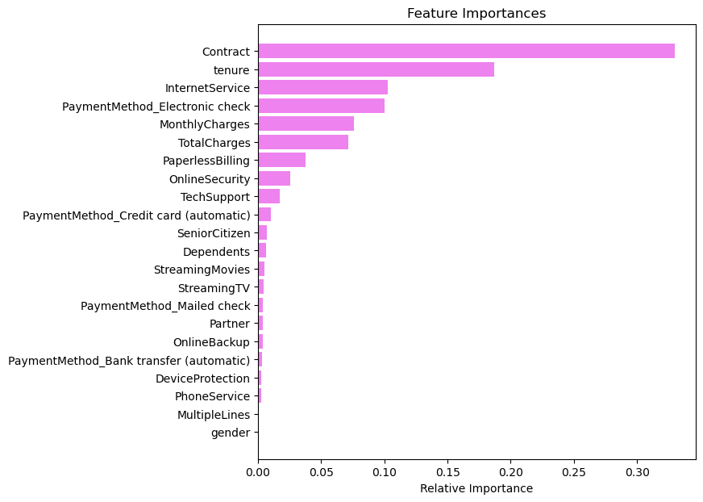

```python
importances = rf_grid_search.feature_importances_
indices = np.argsort(importances)
feature_names = list(X.columns)

plt.figure(figsize=(7,7))
plt.title("Feature Importances")
plt.barh(range(len(indices)), importances[indices], color='violet')
plt.yticks(range(len(indices)), [feature_names[i] for i in indices])
plt.xlabel('Relative Importance')
```

```
0.7045333333333333
0.6950959488272921
```

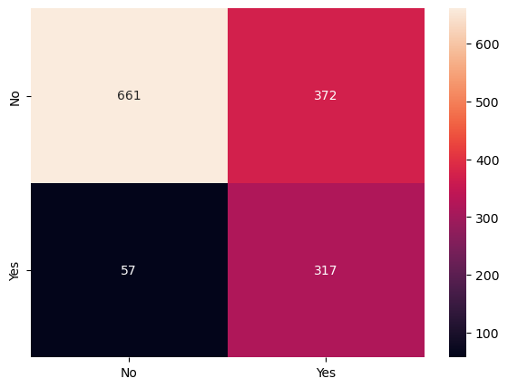

```python
print(rf_grid_search.score(X_train_norm , y_train))
print(rf_grid_search.score(X_test_norm , y_test))
y_predict = rf_grid_search.predict(X_test_norm)

cm = confusion_matrix(y_test, y_predict, labels=[0, 1])

df_cm = pd.DataFrame(cm, index = [i for i in ["No","Yes"]],
                  columns = [i for i in ["No","Yes"]])
plt.figure(figsize = (7,5))
sns.heatmap(df_cm, annot=True ,fmt='g');
```

```python
print(classification_report(y_test,y_predict))
```

```
              precision    recall  f1-score   support

           0       0.92      0.64      0.75      1033
           1       0.46      0.85      0.60       374

    accuracy                           0.70      1407
   macro avg       0.69      0.74      0.68      1407
weighted avg       0.80      0.70      0.71      1407
```

#### Differences observed in performance in Q3.c and Q3.d

With the RandomForest classifier without any tuning, though we could achieve 99.7% accuracy on the training data, we could get only 78.5% on the testing data. Clearly the model was overfitting to the training data.

With above parameters, we could achieve accuracy on the testing data to 70% however, we got 85% recall score for 1. Recall score in the original random forest was 48%. By hyper parameter tuning using grid search, we could increase the recall score of 1 to 85%.

#### E. Train a model using Adaboost and check the performance of the model on train and test data ( 4 marks )

```python
adaboost = AdaBoostClassifier(random_state=1)
adaboost = adaboost.fit(X_train_norm, y_train)
```

```python
print(adaboost.score(X_train_norm, y_train))
print(adaboost.score(X_test_norm, y_test))
```

```
0.8097777777777778
0.7917555081734187
```

```python
# Importance of each features in percentage

print(pd.DataFrame(adaboost.feature_importances_, columns = ["Importance"], index = X_train.columns).sort_values("Importance", ascending=False))
```

```
                                         Importance
TotalCharges                                   0.26
tenure                                         0.22
MonthlyCharges                                 0.16
Contract                                       0.12
InternetService                                0.04
DeviceProtection                               0.02
PaperlessBilling                               0.02
StreamingMovies                                0.02
StreamingTV                                    0.02
SeniorCitizen                                  0.02
OnlineBackup                                   0.02
OnlineSecurity                                 0.02
MultipleLines                                  0.02
PhoneService                                   0.02
PaymentMethod_Electronic check                 0.02
PaymentMethod_Bank transfer (automatic)        0.00
PaymentMethod_Credit card (automatic)          0.00
gender                                         0.00
TechSupport                                    0.00
Dependents                                     0.00
Partner                                        0.00
PaymentMethod_Mailed check                     0.00
```

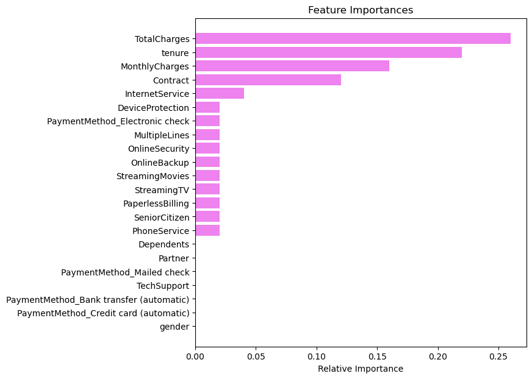

```python
importances = adaboost.feature_importances_
indices = np.argsort(importances)
feature_names = list(X.columns)

plt.figure(figsize=(7,7))
plt.title("Feature Importances")
plt.barh(range(len(indices)), importances[indices], color='violet')
plt.yticks(range(len(indices)), [feature_names[i] for i in indices])
plt.xlabel('Relative Importance')
```

```
0.8097777777777778
0.7917555081734187
```

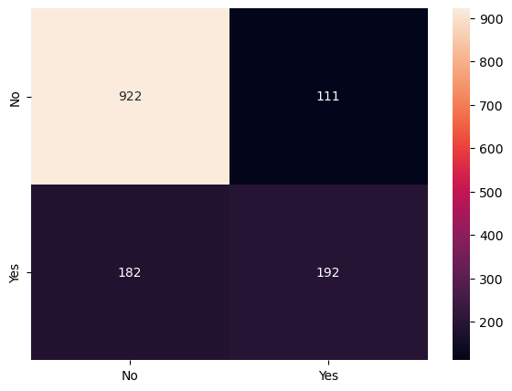

```python
print(adaboost.score(X_train_norm , y_train))
print(adaboost.score(X_test_norm , y_test))
y_predict = adaboost.predict(X_test_norm)

cm = confusion_matrix(y_test, y_predict, labels=[0, 1])

df_cm = pd.DataFrame(cm, index = [i for i in ["No","Yes"]],
                  columns = [i for i in ["No","Yes"]])
plt.figure(figsize = (7,5))
sns.heatmap(df_cm, annot=True ,fmt='g');
```

```python
print(classification_report(y_test,y_predict))
```

```
              precision    recall  f1-score   support

           0       0.84      0.89      0.86      1033
           1       0.63      0.51      0.57       374

    accuracy                           0.79      1407
   macro avg       0.73      0.70      0.72      1407
weighted avg       0.78      0.79      0.78      1407
```

#### F. Use grid search and improve the performance of the Adaboost model , check the performance of the model on train and test data , provide the differences observed in performance in Q3.e and Q3.f ( 5 marks )

```python
ada_params = {
                'n_estimators': [10, 25, 50, 100, 150],
                'learning_rate': [(0.97 + x / 100) for x in range(0, 8)],
                'algorithm': ['SAMME', 'SAMME.R']
             }
```

```python
# Perform Grid Search for Adaboost
grid_search = GridSearchCV(estimator=AdaBoostClassifier(random_state=1),
                              param_grid=ada_params, cv=5, scoring = metrics.make_scorer(metrics.recall_score), n_jobs=-1)
grid_search.fit(X_train_norm, y_train)
```

```
GridSearchCV(cv=5, estimator=AdaBoostClassifier(random_state=1), n_jobs=-1,
             param_grid={'algorithm': ['SAMME', 'SAMME.R'],
                         'learning_rate': [0.97, 0.98, 0.99, 1.0, 1.01, 1.02,
                                           1.03, 1.04],
                         'n_estimators': [10, 25, 50, 100, 150]},
             scoring=make_scorer(recall_score))
```

```python
ada_grid_search = grid_search.best_estimator_
ada_grid_search
```

```
AdaBoostClassifier(learning_rate=0.97, n_estimators=10, random_state=1)
```

```python
# Importance of each features in percentage

print(pd.DataFrame(ada_grid_search.feature_importances_, columns = ["Importance"], index = X_train.columns).sort_values("Importance", ascending=False))
```

```
                                         Importance
tenure                                          0.4
Contract                                        0.3
InternetService                                 0.2
StreamingMovies                                 0.1
gender                                          0.0
StreamingTV                                     0.0
PaymentMethod_Electronic check                  0.0
PaymentMethod_Credit card (automatic)           0.0
PaymentMethod_Bank transfer (automatic)         0.0
TotalCharges                                    0.0
MonthlyCharges                                  0.0
PaperlessBilling                                0.0
TechSupport                                     0.0
SeniorCitizen                                   0.0
DeviceProtection                                0.0
OnlineBackup                                    0.0
OnlineSecurity                                  0.0
MultipleLines                                   0.0
PhoneService                                    0.0
Dependents                                      0.0
Partner                                         0.0
PaymentMethod_Mailed check                      0.0
```

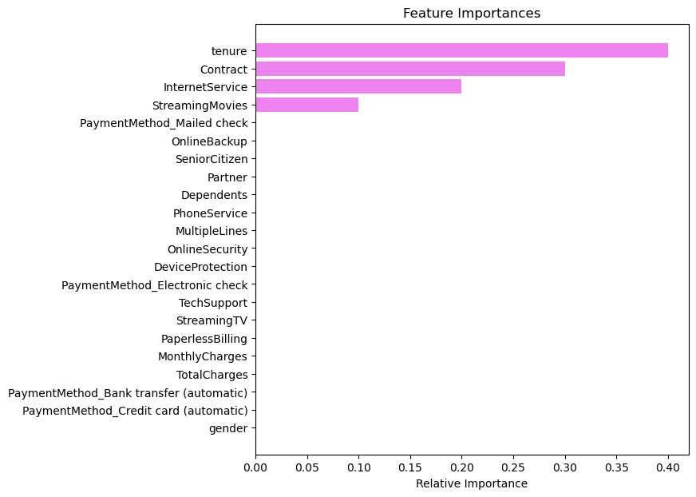

```python
importances = ada_grid_search.feature_importances_
indices = np.argsort(importances)
feature_names = list(X.columns)

plt.figure(figsize=(7,7))
plt.title("Feature Importances")
plt.barh(range(len(indices)), importances[indices], color='violet')
plt.yticks(range(len(indices)), [feature_names[i] for i in indices])
plt.xlabel('Relative Importance')
```

```
0.7845333333333333
0.7739872068230277
```

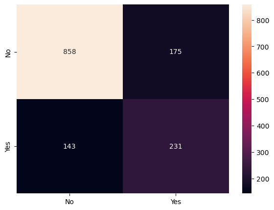

```python
print(ada_grid_search.score(X_train_norm , y_train))
print(ada_grid_search.score(X_test_norm , y_test))
y_predict = ada_grid_search.predict(X_test_norm)

cm = confusion_matrix(y_test, y_predict, labels=[0, 1])

df_cm = pd.DataFrame(cm, index = [i for i in ["No","Yes"]],
                  columns = [i for i in ["No","Yes"]])
plt.figure(figsize = (7,5))
sns.heatmap(df_cm, annot=True ,fmt='g');
```

```python
print(classification_report(y_test,y_predict))
```

```
              precision    recall  f1-score   support

           0       0.86      0.83      0.84      1033
           1       0.57      0.62      0.59       374

    accuracy                           0.77      1407
   macro avg       0.71      0.72      0.72      1407
weighted avg       0.78      0.77      0.78      1407
```

#### Differences observed in performance in Q3.e and Q3.f

With the AdaBoost classifier without any tuning, though we could achieve 81% accuracy on the training data, we could get 79% on the testing data. There is no overfitting observed on training data in ADA Boost.

learning_rate = 0.97, n_estimators = 10

With above parameters, we could achieve accuracy on the testing data to 77.4% however, we got 62% recall score for 1. Recall score in the original AdaBoost was 51%. By hyper parameter tuning using grid search, we could increase the recall score of 1 to 62%.

#### G. Train a model using GradientBoost and check the performance of the model on train and test data ( 4 marks )

```python
gradientboost = GradientBoostingClassifier(random_state=1)
gradientboost = gradientboost.fit(X_train_norm, y_train)
```

```python
print(gradientboost.score(X_train_norm, y_train))
print(gradientboost.score(X_test_norm, y_test))
```

```
0.8302222222222222
0.7945984363894811
```

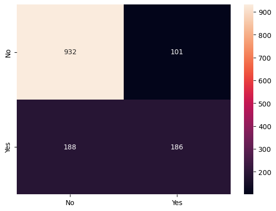

```python
y_predict = gradientboost.predict(X_test_norm)

cm = confusion_matrix(y_test, y_predict, labels=[0, 1])

df_cm = pd.DataFrame(cm, index = [i for i in ["No","Yes"]],
                  columns = [i for i in ["No","Yes"]])
plt.figure(figsize = (7,5))
sns.heatmap(df_cm, annot=True ,fmt='g');
```

```python
print(classification_report(y_test,y_predict))
```

```
              precision    recall  f1-score   support

           0       0.83      0.90      0.87      1033
           1       0.65      0.50      0.56       374

    accuracy                           0.79      1407
   macro avg       0.74      0.70      0.71      1407
weighted avg       0.78      0.79      0.79      1407
```

#### H. Use grid search and improve the performance of the GradientBoost model , check the performance of the model on train and test data , provide the differences observed in performance in Q3.g and Q3.h ( 5 marks )

```python
gb_params = {
                'n_estimators': [25, 50, 75, 100],
                'loss': ["log_loss", "exponential"],
                'learning_rate': [0.001, 0.01, 0.02, 0.1],
                'max_depth': [1, 2, 3, 4, 5],
                'max_features': ["log2", "sqrt"],
                #'max_leaf_nodes': [5],
                #'min_samples_leaf': [5],
                #'criterion': ['squared_error']
            }
```

```python
# Perform Grid Search for Gradient boosting
grid_search = GridSearchCV(estimator=GradientBoostingClassifier(random_state=1),
                              param_grid=gb_params, cv=5, scoring = metrics.make_scorer(metrics.recall_score), n_jobs=-1)
grid_search.fit(X_train_norm, y_train)
```

```
GridSearchCV(cv=5, estimator=GradientBoostingClassifier(random_state=1),
             n_jobs=-1,
             param_grid={'learning_rate': [0.001, 0.01, 0.02, 0.1],
                         'loss': ['log_loss', 'exponential'],
                         'max_depth': [1, 2, 3, 4, 5],
                         'max_features': ['log2', 'sqrt'],
                         'n_estimators': [25, 50, 75, 100]},
             scoring=make_scorer(recall_score))
```

```python
gb_grid_search = grid_search.best_estimator_
gb_grid_search
```

```
GradientBoostingClassifier(loss='exponential', max_depth=4, max_features='log2',
                           random_state=1)
```

```python
# Importance of each features in percentage

print(pd.DataFrame(gb_grid_search.feature_importances_, columns = ["Importance"], index = X_train.columns).sort_values("Importance", ascending=False))
```

```
                                         Importance
tenure                                     0.235050
Contract                                   0.210388
MonthlyCharges                             0.126324
InternetService                            0.109696
TotalCharges                               0.102228
PaymentMethod_Electronic check             0.047253
PaperlessBilling                           0.026333
StreamingTV                                0.019768
OnlineSecurity                             0.018637
TechSupport                                0.017680
SeniorCitizen                              0.014464
StreamingMovies                            0.012149
MultipleLines                              0.010706
Dependents                                 0.009178
OnlineBackup                               0.007752
PaymentMethod_Mailed check                 0.007503
PhoneService                               0.007111
gender                                     0.004114
Partner                                    0.003759
PaymentMethod_Credit card (automatic)      0.003726
PaymentMethod_Bank transfer (automatic)    0.003621
DeviceProtection                           0.002559
```

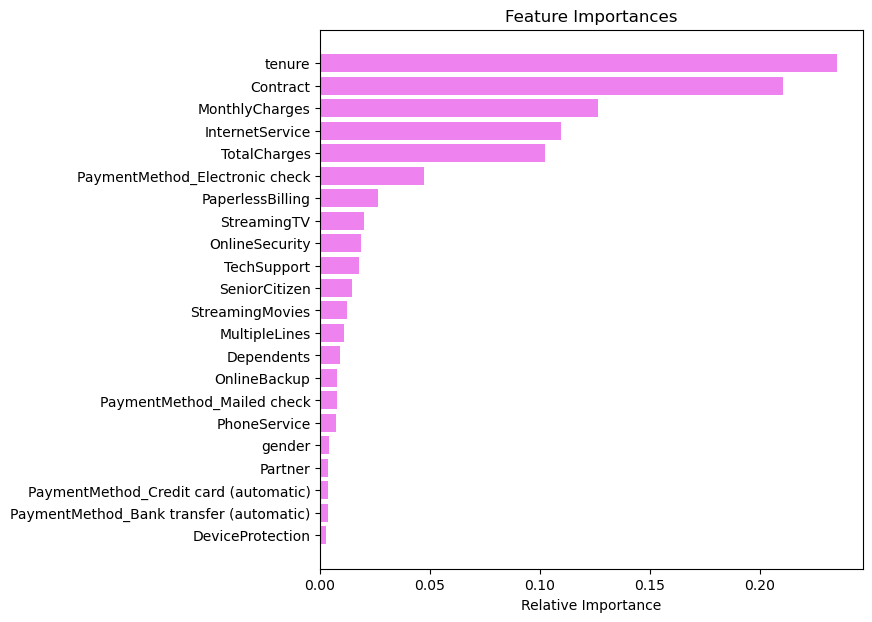

```python
importances = gb_grid_search.feature_importances_
indices = np.argsort(importances)
feature_names = list(X.columns)

plt.figure(figsize=(7,7))
plt.title("Feature Importances")
plt.barh(range(len(indices)), importances[indices], color='violet')
plt.yticks(range(len(indices)), [feature_names[i] for i in indices])
plt.xlabel('Relative Importance')
```

```
0.8288
0.8038379530916845
```

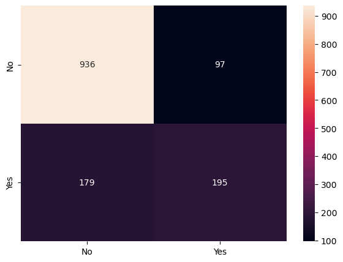

```python
print(gb_grid_search.score(X_train_norm , y_train))
print(gb_grid_search.score(X_test_norm , y_test))
y_predict = gb_grid_search.predict(X_test_norm)

cm = confusion_matrix(y_test, y_predict, labels=[0, 1])

df_cm = pd.DataFrame(cm, index = [i for i in ["No","Yes"]],
                  columns = [i for i in ["No","Yes"]])
plt.figure(figsize = (7,5))
sns.heatmap(df_cm, annot=True ,fmt='g');
```

```python
print(classification_report(y_test,y_predict))
```

```
              precision    recall  f1-score   support

           0       0.84      0.91      0.87      1033
           1       0.67      0.52      0.59       374

    accuracy                           0.80      1407
   macro avg       0.75      0.71      0.73      1407
weighted avg       0.79      0.80      0.80      1407
```

#### Differences observed in performance in Q3.g and Q3.h

With above parameters, we could achieve accuracy on the testing data to 80% however, we got 52% recall score for 1. Recall score in the original GradientBoosting was 50%. By hyper parameter tuning using grid search, we could increase the recall score of 1 slightly to 52%.

#### I. Provide detailed analysis of the below steps (4 marks ) :

##### - Compare the performance of each model in train stage and test stage

| Model | Accuracy on Training Data | Accuracy on Testing Data | Recall for Churn="Yes" on Testing Data |
| --- | --- | --- | --- |
| Decision Tree | 99.7155 % | 71.1442 % | 52 % |
| Decision Tree with Regularisation | 80.1066 % | 78.2516 % | 56 % |
| Decision Tree with Hyper Parameter Tuning | 76.5333 % | 74.9111 % | 60 % |
| Random Forest | 99.7155 % | 78.5359 % | 48 % |
| Random Forest with Hyper Parameter Tuning | 70.4533 % | 69.5096 % | 85 % |
| AdaBoost | 80.9777 % | 79.1755 % | 51 % |
| AdaBoost with Hyper Parameter Tuning | 78.4533 % | 77.3987 % | 62 % |
| Gradient Boost | 83.0222 % | 79.4598 % | 50 % |
| Gradient Boost with Hyper Parameter Tuning | 82.88 % | 80.383 % | 52 % |

##### - Provide your observation on which model performed the best

In my observation, Random Forest with Hyper Parameter Tuning performed the best with Recall score of 85% for Churn="Yes" on Testing Data. This means, with this model, we are able to predict the attributes affecting the customer churn efficiently. Also, note that overall model accuracy is 70%.

##### - Provide your reasoning on why the model performed best

Random Forest with Hyper Parameter Tuning performed best because we could tune class weight as per the dataset. In the dataset, there is 26.58% of the data for Churn="Yes" and 73.42% of the data for Churn="No". We set the class weight parameter reflecting this imbalance by setting class_weight = {0: 0.2658, 1: 0.7342}. Hence this model could predict the customer churn more effectively.

##### - Provide your final conclusion on your observation

We could get recall score for Customer Churn="Yes" to 85%

We could predict 317 customers churn accurately out of 374, with recall of 85%. This is the best result we seen so far in any model.

Also, note the below features impacting the customer churn more as per the feature importances:

- Contract 32.9744 %
- tenure 18.7105 %
- InternetService 10.2792 %
- PaymentMethod_Electronic check 10.0221 %
- MonthlyCharges 7.56950 %
- TotalCharges 7.11550 %
- PaperlessBilling 3.79030 %
- OnlineSecurity 2.54930 %
- TechSupport 1.74240 %
- PaymentMethod_Credit card (automatic) 1.00470 %

#### Let's find values of each of these features from the original dataset, so that we can tell the company which customers to focus on

##### Plot bar charts of count of each of features where Churn="Yes"

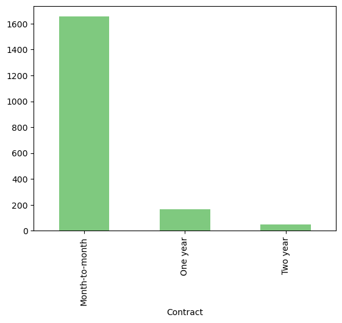

```python
pd.crosstab(df_churn['Contract'], df_churn['Churn'])['Yes'].plot(kind="bar",stacked=True, colormap='Accent');
```

##### - Clearly there is higher churn of customers who are on Month-to-month contract

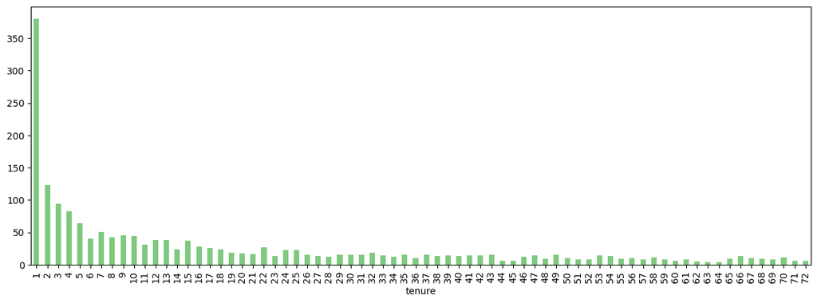

```python
pd.crosstab(df_churn['tenure'], df_churn['Churn'])['Yes'].plot(kind="bar",stacked=True, figsize=(15,5), colormap='Accent');
```

##### - Clearly there is higher churn of customers who's tenure is less

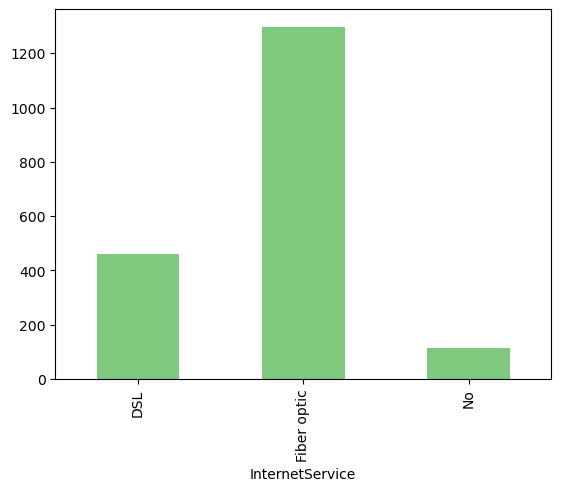

```python
pd.crosstab(df_churn['InternetService'], df_churn['Churn'])['Yes'].plot(kind="bar",stacked=True, colormap='Accent');
```

##### - Clearly there is higher churn of customers who are on Fiber optic connection

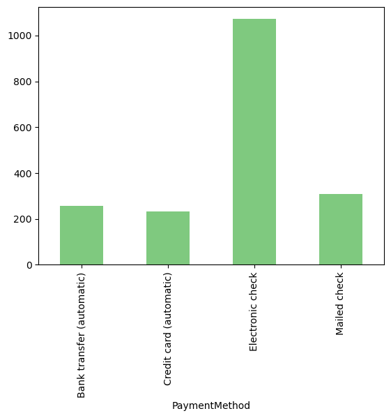

```python
pd.crosstab(df_churn['PaymentMethod'], df_churn['Churn'])['Yes'].plot(kind="bar",stacked=True, colormap='Accent');
```

##### - Clearly there is higher churn of customers who are on Electronic check payment method

### Conclusion

#### As per my Data Analysis, I advise the company to focus on retaining customers who are on:

- Month-to-month Contract
- Lesser tenure
- Fibre optic InternetService
- Electronic check PaymentMethod